# Fisher–ACM’s–FUZZY-C-MEANS

Andres Useche

Descarga de librerias necesarias

```r
#Librerias
#install.packages("readxl")
library(readxl)
#install.packages('FactoMineR')
#install.packages('factoextra')
#install.packages("ggrepel")
library(FactoMineR)
#install.packages("rlang")
library(rlang)
library(factoextra)
library("ggrepel")
library(dplyr)
```

```r
library(ggplot2)
library(writexl)
library(ppclust)
library(tidyr)

#if(!require(plotly)) install.packages("plotly")
library(plotly)
#if(!require(ggalluvial)) install.packages("ggalluvial")
library(ggalluvial)
library(dplyr)
```

## Carga de datos

```r
datos_1 <- read_excel("C:/Users/usech/Downloads/ver1_2.xlsx")
datos_1$id <- 1:nrow(datos_1)

head(datos_1)
```

```
## # A tibble: 6 × 25
##   `Año del hecho` `Sexo de la victima` `Grupo Mayor Menor de Edad` `Ciclo Vital`
##             <dbl> <chr>                <chr>                       <chr>
## 1            2024 Mujer                b) Mayores de Edad (>18 añ… (29 a 59) Ad…
## 2            2024 Mujer                b) Mayores de Edad (>18 añ… (29 a 59) Ad…
## 3            2024 Hombre               a) Menores de Edad (<18 añ… (12 a 17) Ad…
## 4            2024 Hombre               a) Menores de Edad (<18 añ… (12 a 17) Ad…
## 5            2024 Hombre               b) Mayores de Edad (>18 añ… (29 a 59) Ad…
## 6            2024 Hombre               b) Mayores de Edad (>18 añ… (18 a 28) Ju…
## # ℹ 21 more variables: Escolaridad <chr>, `Estado Civil` <chr>,
## #   `Tipo de Discapacidad` <chr>, `Orientación Sexual` <chr>,
## #   `Identidad de Género` <chr>, `Pertenencia Grupal` <chr>,
## #   `Municipio del hecho DANE` <chr>, `Departamento del hecho DANE` <chr>,
## #   `Localidad del Hecho` <chr>, `Zona del Hecho` <chr>,
## #   `Escenario del Hecho` <chr>, `Actividad Durante el Hecho` <chr>,
## #   `Circunstancia del Hecho Detallada` <chr>, `Contexto del Hecho` <chr>, …
```

```r
colnames(datos_1)
```

```
##  [1] "Año del hecho"
##  [2] "Sexo de la victima"
##  [3] "Grupo Mayor Menor de Edad"
##  [4] "Ciclo Vital"
##  [5] "Escolaridad"
##  [6] "Estado Civil"
##  [7] "Tipo de Discapacidad"
##  [8] "Orientación Sexual"
##  [9] "Identidad de Género"
## [10] "Pertenencia Grupal"
## [11] "Municipio del hecho DANE"
## [12] "Departamento del hecho DANE"
## [13] "Localidad del Hecho"
## [14] "Zona del Hecho"
## [15] "Escenario del Hecho"
## [16] "Actividad Durante el Hecho"
## [17] "Circunstancia del Hecho Detallada"
## [18] "Contexto del Hecho"
## [19] "Mecanismo Causal de la Lesión no Fatal"
## [20] "Diagnostico Topográfico de la Lesión no Fatal"
## [21] "Sexo del Agresor"
## [22] "Presunto Agresor Detallado"
## [23] "Factor Desencadenante de la Agresión"
## [24] "Días de Incapacidad Medicolegal"
## [25] "id"
```

Curaduria

```r
datos_1$`Contexto del Hecho` <- dplyr::recode(
  datos_1$`Contexto del Hecho`,
  "6 Lesiones no Fatales por Violencia de Pareja" = "Violencia de pareja",
  "4 Lesiones no Fatales por Violencia entre otros Familiares" = "Violencia entre familiares",
  "3 Lesiones no Fatales contra Niños, Niñas y Adolescentes por Violencia Intrafamiliar" = "Violencia contra NNA",
  "5 Lesiones no Fatales contra el Adulto Mayor por Violencia Intrafamiliar" = "Violencia contra el adulto mayor",
  .default = datos_1$`Contexto del Hecho`
)


names(datos_1) <- gsub("Circunstancia.del.Hecho.Detallada",
                        "Circunstancia del Hecho",
                        names(datos_1))



colnames(datos_1)
```

```
##  [1] "Año del hecho"
##  [2] "Sexo de la victima"
##  [3] "Grupo Mayor Menor de Edad"
##  [4] "Ciclo Vital"
##  [5] "Escolaridad"
##  [6] "Estado Civil"
##  [7] "Tipo de Discapacidad"
##  [8] "Orientación Sexual"
##  [9] "Identidad de Género"
## [10] "Pertenencia Grupal"
## [11] "Municipio del hecho DANE"
## [12] "Departamento del hecho DANE"
## [13] "Localidad del Hecho"
## [14] "Zona del Hecho"
## [15] "Escenario del Hecho"
## [16] "Actividad Durante el Hecho"
## [17] "Circunstancia del Hecho"
## [18] "Contexto del Hecho"
## [19] "Mecanismo Causal de la Lesión no Fatal"
## [20] "Diagnostico Topográfico de la Lesión no Fatal"
## [21] "Sexo del Agresor"
## [22] "Presunto Agresor Detallado"
## [23] "Factor Desencadenante de la Agresión"
## [24] "Días de Incapacidad Medicolegal"
## [25] "id"
```

# FISHER

Algunas asociaciones importantes no pueden evaluarse mediante la prueba Chi-cuadrado de independencia, debido al incumplimiento de sus supuestos (por ejemplo, bajas frecuencias esperadas).En estos casos, se utiliza la prueba exacta de Fisher como alternativa.

```r
pares_fuertes <- data.frame(
  v1 = c(

    "Circunstancia del Hecho",
    "Mecanismo Causal de la Lesión no Fatal",
    "Diagnostico Topográfico de la Lesión no Fatal",
    "Sexo del Agresor",
    "Escenario del Hecho",
    "Mecanismo Causal de la Lesión no Fatal",
    "Actividad Durante el Hecho",
    "Escenario del Hecho",
    "Zona del Hecho",
    "Escenario del Hecho",
    "Grupo Mayor Menor de Edad",
    "Sexo del Agresor",
    "Circunstancia del Hecho",
    "Presunto Agresor Detallado",
    "Circunstancia del Hecho"
  ),

  v2 = c(

    "Factor Desencadenante de la Agresión",
    "Días de Incapacidad Medicolegal",
    "Días de Incapacidad Medicolegal",
    "Presunto Agresor Detallado",
    "Actividad Durante el Hecho",
    "Diagnostico Topográfico de la Lesión no Fatal",
    "Sexo del Agresor",
    "Presunto Agresor Detallado",
    "Escenario del Hecho",
    "Sexo del Agresor",
    "Días de Incapacidad Medicolegal",
    "Sexo de la victima",
    "Presunto Agresor Detallado",
    "Factor Desencadenante de la Agresión",
    "Ciclo Vital"
  )
)
```

Prueba exacta de Fisher

```r
resultados_fisher <- data.frame()

for(i in 1:nrow(pares_fuertes)){

  var1 <- pares_fuertes$v1[i]
  var2 <- pares_fuertes$v2[i]

  tabla <- table(datos_1[[var1]], datos_1[[var2]])


  test <- fisher.test(
    tabla,
    simulate.p.value = TRUE,
    B= 1000000

  )

  resultados_fisher <- rbind(
    resultados_fisher,
    data.frame(
      Variable_1 = var1,
      Variable_2 = var2,
      p_value = test$p.value,
      filas = nrow(tabla),
      columnas = ncol(tabla)
    )
  )

}

resultados_fisher
```

```
##                                       Variable_1
## 1                        Circunstancia del Hecho
## 2         Mecanismo Causal de la Lesión no Fatal
## 3  Diagnostico Topográfico de la Lesión no Fatal
## 4                               Sexo del Agresor
## 5                            Escenario del Hecho
## 6         Mecanismo Causal de la Lesión no Fatal
## 7                     Actividad Durante el Hecho
## 8                            Escenario del Hecho
## 9                                 Zona del Hecho
## 10                           Escenario del Hecho
## 11                     Grupo Mayor Menor de Edad
## 12                              Sexo del Agresor
## 13                       Circunstancia del Hecho
## 14                    Presunto Agresor Detallado
```

[output cut: 17 more lines]

# Analisis de correspondencia Multiple (ACM)

## ACM I

Se selecionan las variables categorias que entran al ACM I

```r
cat_vars <- c( "Sexo de la victima",

               "Ciclo Vital",
               "Escolaridad",
               "Estado Civil",
               "Pertenencia Grupal",
               "Zona del Hecho",
               "Escenario del Hecho",
               "Actividad Durante el Hecho",
               "Circunstancia del Hecho",
               "Contexto del Hecho",
               "Sexo del Agresor",
               "Presunto Agresor Detallado",
               "Mecanismo Causal de la Lesión no Fatal",
               "Diagnostico Topográfico de la Lesión no Fatal",
               "Factor Desencadenante de la Agresión",
               "Días de Incapacidad Medicolegal",
               "Tipo de Discapacidad",
               "Orientación Sexual"


)
```

Se genera una copia del conjunto de datos, se recodifica una de las variables categóricas para mejorar su interpretación y se distinguen las variables e individuos suplementarios,los cuales no participan en la construcción del espacio factorial del análisis pero si se pueden representar en los planos factoriales.

```r
df_clean <- datos_1[, cat_vars]


valores_invalidos <- c(
  "Sin información", "sin información", "SIN INFORMACIÓN",
  "Sin informacion", "sin informacion",
  "Por determinar", "por determinar",
  "Otros", "otros",
  "Sin información/Otros", "sin informacion/otros"
)

invalid_matrix <- as.data.frame(
  lapply(df_clean, function(x) x %in% valores_invalidos)
)
invalid_ratio <- rowMeans(invalid_matrix, na.rm = TRUE)
```

Los registros que presentan más del 15% de valores faltantes o categorías no válidas son tratados como individuos suplementarios, por lo que no participan en la construcción del espacio factorial, pero se proyectan posteriormente para su interpretación.

```r
ind_sup <- which(invalid_ratio > 0.15)

length(ind_sup)
```

```
## [1] 2530
```

```r
df_clean[] <- lapply(df_clean, as.factor)
```

Categorías tratadas como suplementarias: se incluyen aquellas con baja asociación estadística dentro del conjunto de variables, así como aquellas que presentan menos del 80% de información válida. Estas no participan en la construcción del espacio factorial, pero se proyectan para su interpretación.

```r
quali_sup_vars <- c(
  "Orientación.Sexual",
  "Pertenencia.Grupal",
  "Zona.del.Hecho",
   "Escenario.del.Hecho",
  "Actividad.Durante.el.Hecho",
  "Mecanismo.Causal.de.la.Lesión.no.Fatal",
  "Diagnostico.Topográfico.de.la.Lesión.no.Fatal",
  "Días.de.Incapacidad Medicolegal",
  "Tipo.de.Discapacidad"

)

names(df_clean) <- make.names(names(df_clean))
names(df_clean)
```

```
##  [1] "Sexo.de.la.victima"
##  [2] "Ciclo.Vital"
##  [3] "Escolaridad"
##  [4] "Estado.Civil"
##  [5] "Pertenencia.Grupal"
##  [6] "Zona.del.Hecho"
##  [7] "Escenario.del.Hecho"
##  [8] "Actividad.Durante.el.Hecho"
##  [9] "Circunstancia.del.Hecho"
## [10] "Contexto.del.Hecho"
## [11] "Sexo.del.Agresor"
## [12] "Presunto.Agresor.Detallado"
## [13] "Mecanismo.Causal.de.la.Lesión.no.Fatal"
## [14] "Diagnostico.Topográfico.de.la.Lesión.no.Fatal"
## [15] "Factor.Desencadenante.de.la.Agresión"
## [16] "Días.de.Incapacidad.Medicolegal"
## [17] "Tipo.de.Discapacidad"
## [18] "Orientación.Sexual"
```

```r
quali_sup <- which(names(df_clean) %in% quali_sup_vars)



niveles_excluir <- valores_invalidos
```

Construcción del ACM I

```r
ACM_datos<- MCA(
  df_clean,
  quali.sup = quali_sup,
  ind.sup = ind_sup,
  graph = FALSE
)



summary(ACM_datos)
```

```
##
## Call:
## MCA(X = df_clean, ind.sup = ind_sup, quali.sup = quali_sup, graph = FALSE)
##
##
## Eigenvalues
##                        Dim.1   Dim.2   Dim.3   Dim.4   Dim.5   Dim.6   Dim.7
## Variance               0.414   0.252   0.199   0.173   0.169   0.164   0.163
## % of var.              8.281   5.038   3.973   3.459   3.371   3.281   3.256
## Cumulative % of var.   8.281  13.319  17.292  20.751  24.121  27.402  30.658
##                        Dim.8   Dim.9  Dim.10  Dim.11  Dim.12  Dim.13  Dim.14
## Variance               0.157   0.148   0.137   0.128   0.125   0.122   0.118
## % of var.              3.143   2.967   2.749   2.560   2.504   2.448   2.368
## Cumulative % of var.  33.801  36.768  39.516  42.076  44.580  47.028  49.396
##                       Dim.15  Dim.16  Dim.17  Dim.18  Dim.19  Dim.20  Dim.21
## Variance               0.116   0.110   0.103   0.102   0.101   0.101   0.100
## % of var.              2.313   2.193   2.068   2.041   2.015   2.010   2.002
## Cumulative % of var.  51.709  53.902  55.970  58.011  60.026  62.037  64.038
##                       Dim.22  Dim.23  Dim.24  Dim.25  Dim.26  Dim.27  Dim.28
## Variance               0.100   0.100   0.099   0.099   0.096   0.094   0.091
## % of var.              1.998   1.996   1.988   1.977   1.920   1.871   1.825
## Cumulative % of var.  66.037  68.033  70.021  71.997  73.918  75.789  77.613
##                       Dim.29  Dim.30  Dim.31  Dim.32  Dim.33  Dim.34  Dim.35
## Variance               0.087   0.086   0.083   0.080   0.076   0.075   0.074
## % of var.              1.736   1.713   1.669   1.592   1.516   1.506   1.490
## Cumulative % of var.  79.349  81.062  82.731  84.323  85.839  87.345  88.835
##                       Dim.36  Dim.37  Dim.38  Dim.39  Dim.40  Dim.41  Dim.42
## Variance               0.072   0.064   0.057   0.057   0.052   0.044   0.043
## % of var.              1.446   1.282   1.149   1.132   1.040   0.879   0.852
## Cumulative % of var.  90.281  91.563  92.712  93.844  94.884  95.763  96.616
##                       Dim.43  Dim.44  Dim.45  Dim.46  Dim.47  Dim.48  Dim.49
## Variance               0.037   0.037   0.033   0.028   0.015   0.014   0.005
## % of var.              0.739   0.734   0.666   0.561   0.299   0.275   0.110
## Cumulative % of var.  97.355  98.089  98.755  99.317  99.615  99.890 100.000
##                       Dim.50
## Variance               0.000
## % of var.              0.000
## Cumulative % of var. 100.000
##
## Individuals (the 10 first)
```

[output cut: 667 more lines]

```
## Escenario.del.Hecho                                                            0.005
## Actividad.Durante.el.Hecho                                                     0.005
## Mecanismo.Causal.de.la.Lesión.no.Fatal                                         0.040
## Diagnostico.Topográfico.de.la.Lesión.no.Fatal                                  0.034
## Tipo.de.Discapacidad                                                           0.001
## Orientación.Sexual                                                             0.083
##
## Pertenencia.Grupal                                                             |
## Zona.del.Hecho                                                                 |
## Escenario.del.Hecho                                                            |
## Actividad.Durante.el.Hecho                                                     |
## Mecanismo.Causal.de.la.Lesión.no.Fatal                                         |
## Diagnostico.Topográfico.de.la.Lesión.no.Fatal                                  |
## Tipo.de.Discapacidad                                                           |
## Orientación.Sexual                                                             |
```

Valores propios

```r
# Valores propios

vp <- get_eigenvalue(ACM_datos)

vp
```

```
##          eigenvalue variance.percent cumulative.variance.percent
## Dim.1  4.140373e-01     8.280745e+00                    8.280745
## Dim.2  2.519169e-01     5.038337e+00                   13.319083
## Dim.3  1.986271e-01     3.972542e+00                   17.291624
## Dim.4  1.729454e-01     3.458908e+00                   20.750532
## Dim.5  1.685315e-01     3.370629e+00                   24.121161
## Dim.6  1.640441e-01     3.280882e+00                   27.402044
## Dim.7  1.628033e-01     3.256065e+00                   30.658109
## Dim.8  1.571261e-01     3.142522e+00                   33.800631
## Dim.9  1.483474e-01     2.966947e+00                   36.767578
## Dim.10 1.374292e-01     2.748585e+00                   39.516163
## Dim.11 1.279815e-01     2.559630e+00                   42.075793
## Dim.12 1.252005e-01     2.504010e+00                   44.579803
## Dim.13 1.224242e-01     2.448483e+00                   47.028286
## Dim.14 1.183858e-01     2.367716e+00                   49.396002
## Dim.15 1.156666e-01     2.313333e+00                   51.709335
## Dim.16 1.096378e-01     2.192757e+00                   53.902092
## Dim.17 1.034002e-01     2.068004e+00                   55.970096
## Dim.18 1.020695e-01     2.041390e+00                   58.011486
## Dim.19 1.007480e-01     2.014961e+00                   60.026447
## Dim.20 1.005205e-01     2.010409e+00                   62.036856
## Dim.21 1.000797e-01     2.001593e+00                   64.038449
## Dim.22 9.991897e-02     1.998379e+00                   66.036829
## Dim.23 9.979996e-02     1.995999e+00                   68.032828
## Dim.24 9.939665e-02     1.987933e+00                   70.020761
## Dim.25 9.883493e-02     1.976699e+00                   71.997459
## Dim.26 9.600777e-02     1.920155e+00                   73.917615
## Dim.27 9.355248e-02     1.871050e+00                   75.788664
## Dim.28 9.123589e-02     1.824718e+00                   77.613382
## Dim.29 8.678268e-02     1.735654e+00                   79.349036
## Dim.30 8.564461e-02     1.712892e+00                   81.061928
## Dim.31 8.344983e-02     1.668997e+00                   82.730925
## Dim.32 7.960902e-02     1.592180e+00                   84.323105
## Dim.33 7.578775e-02     1.515755e+00                   85.838860
## Dim.34 7.530874e-02     1.506175e+00                   87.345035
## Dim.35 7.448774e-02     1.489755e+00                   88.834790
## Dim.36 7.230919e-02     1.446184e+00                   90.280974
## Dim.37 6.408153e-02     1.281631e+00                   91.562604
## Dim.38 5.747060e-02     1.149412e+00                   92.712016
## Dim.39 5.657743e-02     1.131549e+00                   93.843565
## Dim.40 5.202306e-02     1.040461e+00                   94.884026
## Dim.41 4.396560e-02     8.793120e-01                   95.763338
## Dim.42 4.261979e-02     8.523958e-01                   96.615734
## Dim.43 3.695670e-02     7.391340e-01                   97.354868
## Dim.44 3.670707e-02     7.341414e-01                   98.089009
## Dim.45 3.332438e-02     6.664876e-01                   98.755497
## Dim.46 2.806201e-02     5.612402e-01                   99.316737
## Dim.47 1.493340e-02     2.986680e-01                   99.615405
## Dim.48 1.374398e-02     2.748796e-01                   99.890285
## Dim.49 5.483156e-03     1.096631e-01                   99.999948
## Dim.50 2.607277e-06     5.214554e-05                  100.000000
```

Contribuciones

```r
var_acm <- get_mca_var(ACM_datos)

# Contribuciones de las categorias a las dimensiones

# Ver las 5 categorías que más contribuyen a las primeras 5 dimensiones

lapply(1:ncol(var_acm$contrib), function(i){

  x <- var_acm$contrib[, i]

  data.frame(
    contribucion = sort(x, decreasing = TRUE)[1:5],
    dimension = colnames(var_acm$contrib)[i]
  )
})
```

```
## [[1]]
##                                             contribucion dimension
## Violencia contra NNA                           11.619196     Dim 1
## Presunto.Agresor.Detallado_Familia nuclear      9.342724     Dim 1
## Estado.Civil_No aplica                          8.815849     Dim 1
## (06 a 11) Infancia                              5.868883     Dim 1
## Circunstancia.del.Hecho_Intolerancia social     5.747085     Dim 1
##
## [[2]]
##                                              contribucion dimension
## Violencia contra el adulto mayor                12.050524     Dim 2
## Estado.Civil_No aplica                          11.849033     Dim 2
## (Más de 60) Adulto Mayor                        10.735311     Dim 2
## Presunto.Agresor.Detallado_Familia extendida     7.487823     Dim 2
## (00 a 05) Primera Infancia                       7.410730     Dim 2
##
## [[3]]
##                                  contribucion dimension
## (Más de 60) Adulto Mayor            18.354280     Dim 3
## Violencia contra el adulto mayor    16.851468     Dim 3
## Violencia entre familiares           9.639448     Dim 3
## (12 a 17) Adolescencia               6.115352     Dim 3
## Estado.Civil_Viudo (a)               5.933868     Dim 3
##
## [[4]]
##                                                                                     contribucion
## (12 a 17) Adolescencia                                                                 13.061047
## Violencia entre familiares                                                              9.338048
## (00 a 05) Primera Infancia                                                              5.418022
## Circunstancia.del.Hecho_Consumo de sustancias                                           5.008340
## Factor.Desencadenante.de.la.Agresión_Consumo de alcohol y/o sustancias psicoactivas     4.909683
##                                                                                     dimension
## (12 a 17) Adolescencia                                                                  Dim 4
## Violencia entre familiares                                                              Dim 4
## (00 a 05) Primera Infancia                                                              Dim 4
## Circunstancia.del.Hecho_Consumo de sustancias                                           Dim 4
## Factor.Desencadenante.de.la.Agresión_Consumo de alcohol y/o sustancias psicoactivas     Dim 4
##
## [[5]]
##                                                                                     contribucion
## Circunstancia.del.Hecho_Consumo de sustancias                                          18.423570
## Factor.Desencadenante.de.la.Agresión_Consumo de alcohol y/o sustancias psicoactivas    16.652997
## Circunstancia.del.Hecho_Conflicto familiar                                             10.391414
## Factor.Desencadenante.de.la.Agresión_Intolerancia, machismo                             8.806590
## Factor.Desencadenante.de.la.Agresión_Otras razones                                      8.057371
##                                                                                     dimension
## Circunstancia.del.Hecho_Consumo de sustancias                                           Dim 5
## Factor.Desencadenante.de.la.Agresión_Consumo de alcohol y/o sustancias psicoactivas     Dim 5
## Circunstancia.del.Hecho_Conflicto familiar                                              Dim 5
## Factor.Desencadenante.de.la.Agresión_Intolerancia, machismo                             Dim 5
## Factor.Desencadenante.de.la.Agresión_Otras razones                                      Dim 5
```

Representación de las categorias en los ejes

```r
# Que tan bien se representa una categoria en una dimensión


lapply(1:ncol(var_acm$cos2), function(i){

  x <- var_acm$cos2[, i]

  data.frame(
    cos2 = sort(x, decreasing = TRUE)[1:5],
    dimension = colnames(var_acm$cos2)[i]
  )
})
```

```
## [[1]]
##                                                   cos2 dimension
## Violencia de pareja                          0.6873920     Dim 1
## Violencia contra NNA                         0.5329143     Dim 1
## Presunto.Agresor.Detallado_Familia nuclear   0.4888600     Dim 1
## Circunstancia.del.Hecho_Conflicto relacional 0.4675109     Dim 1
## Estado.Civil_No aplica                       0.3782508     Dim 1
##
## [[2]]
##                                                   cos2 dimension
## Violencia contra el adulto mayor             0.3186892     Dim 2
## Estado.Civil_No aplica                       0.3093260     Dim 2
## (Más de 60) Adulto Mayor                     0.2889658     Dim 2
## Violencia entre familiares                   0.2201506     Dim 2
## Presunto.Agresor.Detallado_Familia extendida 0.2152123     Dim 2
##
## [[3]]
##                                       cos2 dimension
## (Más de 60) Adulto Mayor         0.3895385     Dim 3
## Violencia contra el adulto mayor 0.3513827     Dim 3
## Violencia entre familiares       0.2362018     Dim 3
## Estado.Civil_Soltero (a)         0.1427320     Dim 3
## (12 a 17) Adolescencia           0.1295709     Dim 3
##
## [[4]]
##                                 cos2 dimension
## (12 a 17) Adolescencia     0.2409541     Dim 4
## Violencia entre familiares 0.1992313     Dim 4
## (29 a 59) Adultez          0.1402004     Dim 4
## Estado.Civil_Soltero (a)   0.1390928     Dim 4
## Estado.Civil_Unión libre   0.1181626     Dim 4
##
## [[5]]
##                                                                                          cos2
## Circunstancia.del.Hecho_Consumo de sustancias                                       0.3434869
## Factor.Desencadenante.de.la.Agresión_Consumo de alcohol y/o sustancias psicoactivas 0.3333603
## Factor.Desencadenante.de.la.Agresión_Intolerancia, machismo                         0.2824322
## Circunstancia.del.Hecho_Conflicto familiar                                          0.1770345
## Circunstancia.del.Hecho_Intolerancia social                                         0.1481490
##                                                                                     dimension
## Circunstancia.del.Hecho_Consumo de sustancias                                           Dim 5
## Factor.Desencadenante.de.la.Agresión_Consumo de alcohol y/o sustancias psicoactivas     Dim 5
## Factor.Desencadenante.de.la.Agresión_Intolerancia, machismo                             Dim 5
## Circunstancia.del.Hecho_Conflicto familiar                                              Dim 5
## Circunstancia.del.Hecho_Intolerancia social                                             Dim 5
```

Varianza explicada

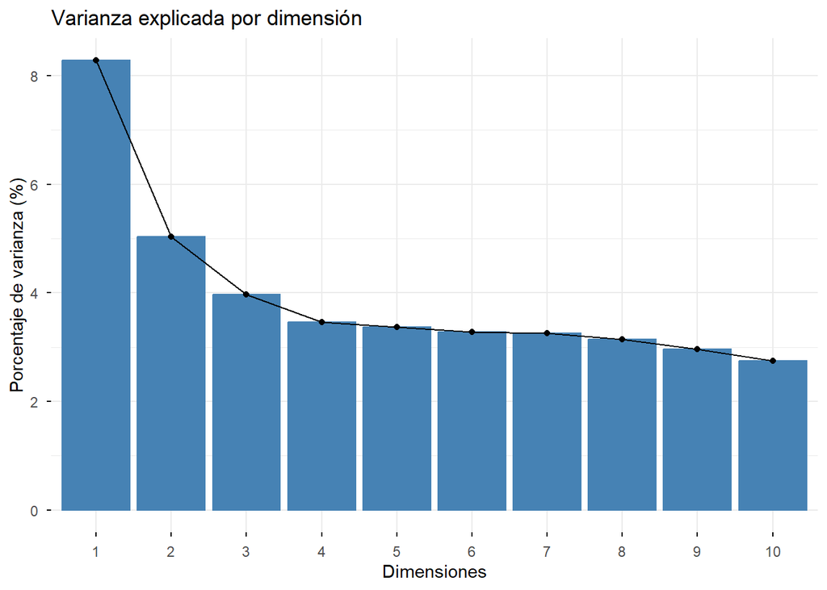

```r
fviz_screeplot(
  ACM_datos,
  title = "Varianza explicada por dimensión",
  xlab = "Dimensiones",
  ylab = "Porcentaje de varianza (%)"
)
```

grafica de barras con las categorias que mejor se representan en la dimensión 1

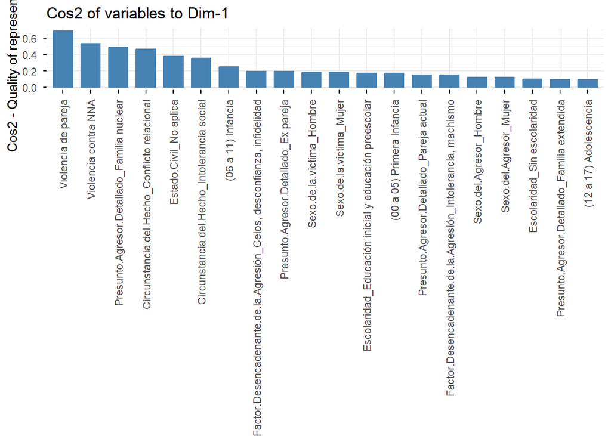

```r
fviz_cos2(ACM_datos, choice = "var", axes = 1, top = 20) +
  theme(axis.text.x = element_text(angle = 90, vjust = 0.5, hjust = 1))
```

### Representación en el plano factorial

Representación en el plano factorial de los individuos y las 12 categorias que mas contribuyen en las construciones de los ejes

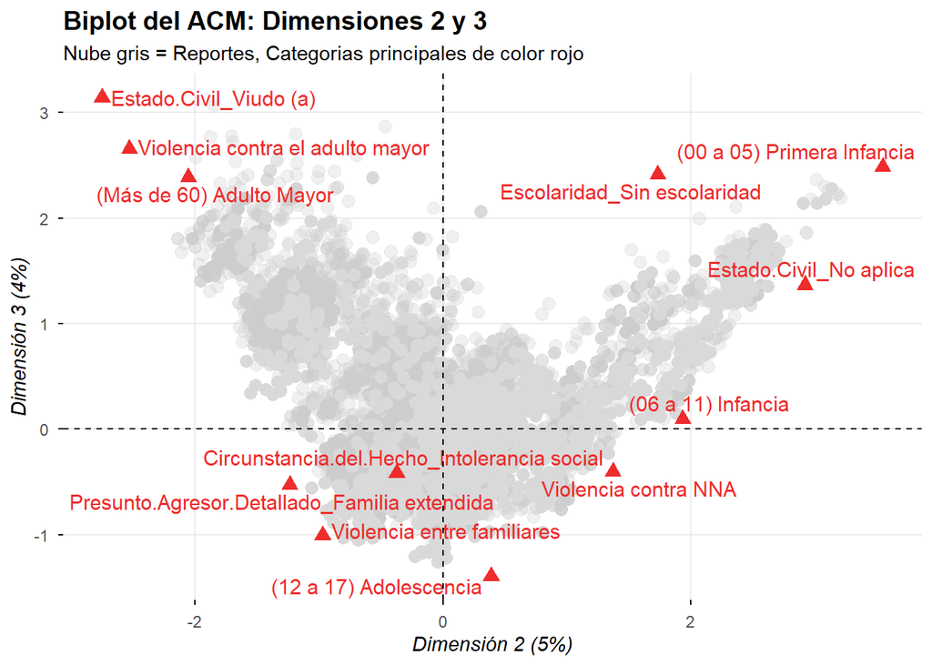

```r
# En el codigo se pueden cambiar los ejes para visualizarlos tambien.

p <-fviz_mca_biplot(
  ACM_datos,
  # 1. Selección de Dimensiones
  axes = c(2,3),

  # 2. Selección y etiquetas
  select.var = list(contrib = 12),
  label = "var",
  repel = TRUE,
  max.overlaps = Inf,

  # 3. Estética de Individuos (Activos y Suplementarios)
  geom.ind = "point",
  col.ind = "grey80",
  alpha.ind = 0.3,

  col.ind.sup = "grey85",
  alpha.ind.sup = 0.2,

  # 4. Estética de Variables
  col.var = "firebrick2",
  pointsize = 3,

  # 5. Formato y Títulos
  ggtheme = theme_minimal() +
    theme(
      panel.grid.minor = element_blank(),
      plot.title = element_text(face = "bold", size = 14),
      axis.title = element_text(face = "italic")
    )
) +
  labs(
    title = "Biplot del ACM: Dimensiones 2 y 3",
    subtitle = "Nube gris = Reportes, Categorias principales de color rojo",
    x = paste0("Dimensión 2 (", round(ACM_datos$eig[2,2], 1), "%)"),
    y = paste0("Dimensión 3 (", round(ACM_datos$eig[3,2], 1), "%)")
  )
p
```

Análisis de la proyección de los individuos en las dos primeras dimensiones factoriales según el sexo de la víctima

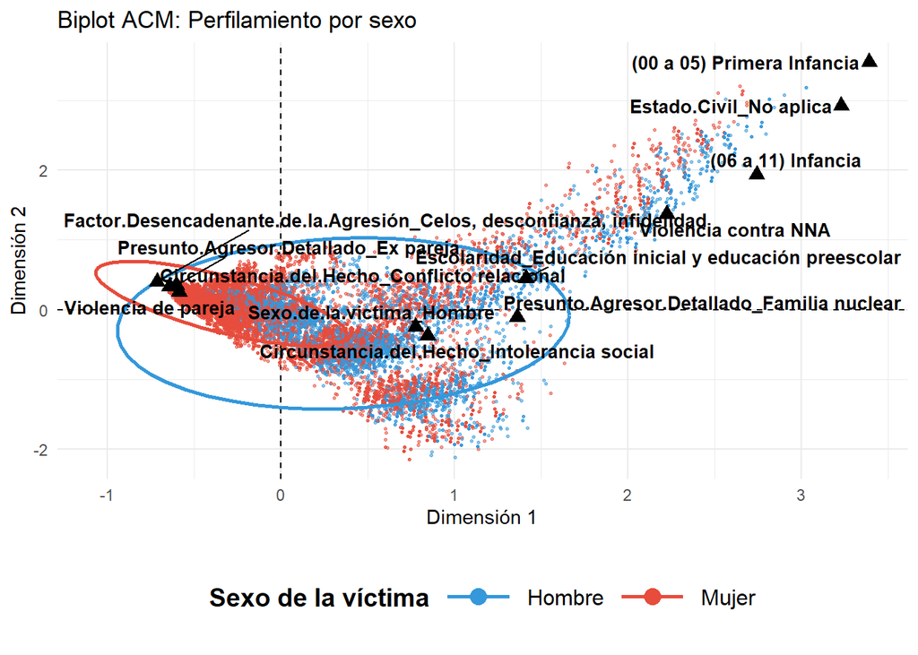

```r
# 1. Extraer individuos ACTIVOS
ind_act <- as.data.frame(ACM_datos$ind$coord[, 1:2])
nombres_act <- rownames(ind_act)


ind_act$Sexo <- as.factor(df_clean[nombres_act, "Sexo.de.la.victima", drop = TRUE])

# 2. Extraer individuos SUPLEMENTARIOS
ind_sup <- as.data.frame(ACM_datos$ind.sup$coord[, 1:2])
nombres_sup <- rownames(ind_sup)


ind_sup$Sexo <- as.factor(df_clean[nombres_sup, "Sexo.de.la.victima", drop = TRUE])

# 3. Unir ambos grupos
todos_ind <- rbind(ind_act, ind_sup)
colnames(todos_ind) <- c("Dim1", "Dim2", "Sexo")

# 4. Preparar las 12 categorías que más contribuyen
res_var <- get_mca_var(ACM_datos)
df_vars <- data.frame(
  Dim1 = res_var$coord[,1],
  Dim2 = res_var$coord[,2],
  Categoria = rownames(res_var$coord),
  Contrib = res_var$contrib[,1]
)
df_top12 <- df_vars[order(-df_vars$Contrib), ][1:12, ]

# 5. GRAFICAR
ggplot() +

  geom_hline(yintercept = 0, linetype = "dashed", color = "black", linewidth = 0.5) +
  geom_vline(xintercept = 0, linetype = "dashed", color = "black", linewidth = 0.5) +

  # Nube de puntos de TODOS los individuos
  geom_point(data = todos_ind,
             aes(x = Dim1, y = Dim2, color = Sexo),
             alpha = 0.55, size = 0.5) +
  stat_ellipse(data = todos_ind,
               aes(x = Dim1, y = Dim2, color = Sexo, group = Sexo),
               level = 0.95, linewidth = 1) +
  geom_point(data = df_top12, aes(x = Dim1, y = Dim2),
             color = "black", shape = 17, size = 3) +
  geom_text_repel(data = df_top12, aes(x = Dim1, y = Dim2, label = Categoria),
                  color = "black", fontface = "bold", size = 3.5, max.overlaps = 20) +


  scale_color_manual(values = c("Hombre" = "#3498DB", "Mujer" = "#E74C3C")) +
  theme_minimal() +
  labs(title = "Biplot ACM: Perfilamiento por sexo",
       x = "Dimensión 1", y = "Dimensión 2",
       color = "Sexo de la víctima") +


  theme(
    legend.position = "bottom",
    legend.title = element_text(size = 14, face = "bold"), # Tamaño del título "Sexo de la víctima"
    legend.text = element_text(size = 12),               # Tamaño de "Hombre" / "Mujer"
    legend.key.size = unit(1.5, "cm")                    # Aumenta el espacio del icono
  ) +


  guides(color = guide_legend(override.aes = list(size = 4, alpha = 1)))
```

Análisis de la proyección de los individuos en las dos primeras dimensiones factoriales según el Contexto del Hecho

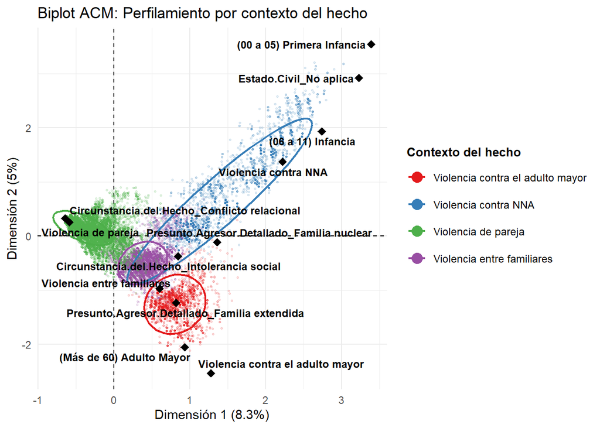

```r
 #Extraer coordenadas de individuos ACTIVOS (Dims 1 y 2)
ind_act <- as.data.frame(ACM_datos$ind$coord[, 1:2])
colnames(ind_act) <- c("Dim1", "Dim2")

# Extraer individuos SUPLEMENTARIOS (Dims 1 y 2)
ind_sup <- as.data.frame(ACM_datos$ind.sup$coord[, 1:2])
colnames(ind_sup) <- c("Dim1", "Dim2")


ind_act$Contexto <- as.factor(df_clean[rownames(ind_act), "Contexto.del.Hecho", drop = TRUE])
ind_sup$Contexto <- as.factor(df_clean[rownames(ind_sup), "Contexto.del.Hecho", drop = TRUE])


todos_ind <- rbind(ind_act, ind_sup)


res_var <- get_mca_var(ACM_datos)
df_vars <- data.frame(
  Dim1 = res_var$coord[, 1],
  Dim2 = res_var$coord[, 2],
  Categoria = rownames(res_var$coord),
  Contrib = res_var$contrib[, 1] + res_var$contrib[, 2]
)
df_top12 <- df_vars[order(-df_vars$Contrib), ][1:12, ]

#  GRAFICAR
ggplot() +

  geom_hline(yintercept = 0, linetype = "dashed", color = "black", linewidth = 0.5) +
  geom_vline(xintercept = 0, linetype = "dashed", color = "black", linewidth = 0.5) +
  # Nube de puntos de individuos coloreados por Contexto
  geom_point(data = todos_ind,
             aes(x = Dim1, y = Dim2, color = Contexto),
             alpha = 0.15, size = 0.5) +


  stat_ellipse(data = todos_ind,
               aes(x = Dim1, y = Dim2, color = Contexto, group = Contexto),
               level = 0.95, linewidth = 0.8) +

  geom_point(data = df_top12, aes(x = Dim1, y = Dim2),
             color = "black", shape = 18, size = 3) +

  geom_text_repel(data = df_top12, aes(x = Dim1, y = Dim2, label = Categoria),
                  color = "black", fontface = "bold", size = 3.2, max.overlaps = 20) +


  scale_color_brewer(palette = "Set1") +
  theme_minimal() +
  labs(title = "Biplot ACM: Perfilamiento por contexto del hecho",

       x = paste0("Dimensión 1 (", round(ACM_datos$eig[1,2], 1), "%)"),
       y = paste0("Dimensión 2 (", round(ACM_datos$eig[2,2], 1), "%)"),
       color = "Contexto del hecho") +

  theme(
    legend.position = "right",
    legend.direction = "vertical",
    legend.title = element_text(size = 10, face = "bold"),
    legend.text = element_text(size = 9),
    legend.key.height = unit(0.8, "cm")
  ) +

  guides(color = guide_legend(override.aes = list(size = 4, alpha = 1)))
```

Análisis de la proyección de los individuos en las dos primeras dimensiones factoriales según el ciclo vital

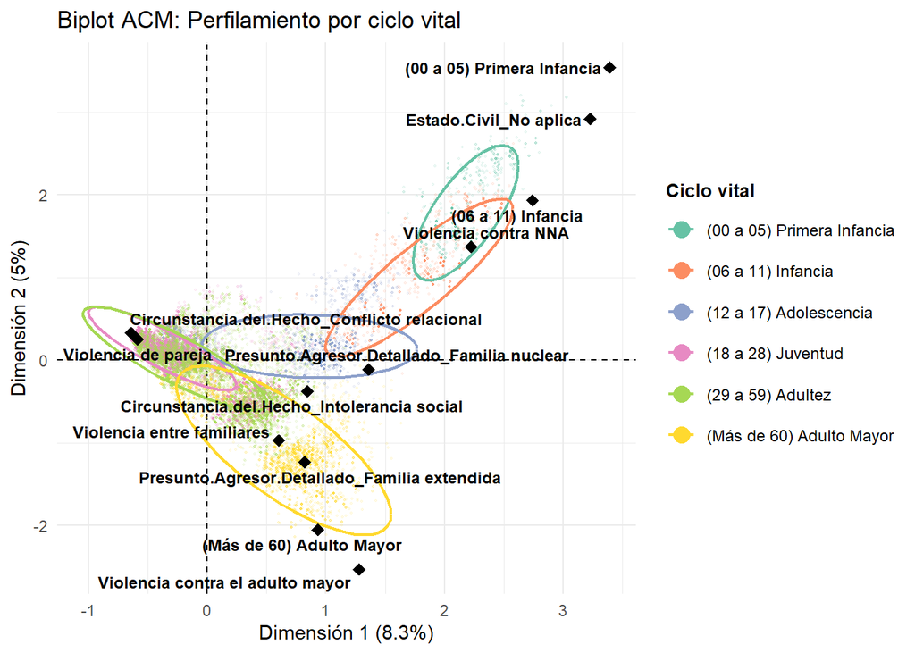

```r
#  Extraer coordenadas de individuos ACTIVOS
ind_act <- as.data.frame(ACM_datos$ind$coord[, 1:2])
colnames(ind_act) <- c("Dim1", "Dim2")

#  Extraer coordenadas de individuos SUPLEMENTARIOS
ind_sup <- as.data.frame(ACM_datos$ind.sup$coord[, 1:2])
colnames(ind_sup) <- c("Dim1", "Dim2")


ind_act$CicloVital <- as.factor(df_clean[rownames(ind_act), "Ciclo.Vital", drop = TRUE])
ind_sup$CicloVital <- as.factor(df_clean[rownames(ind_sup), "Ciclo.Vital", drop = TRUE])

#  Unir ambos grupos
todos_ind <- rbind(ind_act, ind_sup)


res_var <- get_mca_var(ACM_datos)
df_vars <- data.frame(
  Dim1 = res_var$coord[, 1],
  Dim2 = res_var$coord[, 2],
  Categoria = rownames(res_var$coord),
  Contrib = res_var$contrib[, 1] + res_var$contrib[, 2]
)
df_top12 <- df_vars[order(-df_vars$Contrib), ][1:12, ]

# GRAFICAR
ggplot() +

  geom_hline(yintercept = 0, linetype = "dashed", color = "black", linewidth = 0.5) +
  geom_vline(xintercept = 0, linetype = "dashed", color = "black", linewidth = 0.5) +


  # Nube de puntos de individuos coloreados por Ciclo Vital
  geom_point(data = todos_ind,
             aes(x = Dim1, y = Dim2, color = CicloVital),
             alpha = 0.1, size = 0.4) + # Bajamos alpha a 0.1 por la densidad


  stat_ellipse(data = todos_ind,
               aes(x = Dim1, y = Dim2, color = CicloVital, group = CicloVital),
               level = 0.95, linewidth = 0.8) +


  geom_point(data = df_top12, aes(x = Dim1, y = Dim2),
             color = "black", shape = 18, size = 3) +

  geom_text_repel(data = df_top12, aes(x = Dim1, y = Dim2, label = Categoria),
                  color = "black", fontface = "bold", size = 3.2, max.overlaps = 25) +


  scale_color_brewer(palette = "Set2") +
  theme_minimal() +
  labs(title = "Biplot ACM: Perfilamiento por ciclo vital",

       x = paste0("Dimensión 1 (", round(ACM_datos$eig[1,2], 1), "%)"),
       y = paste0("Dimensión 2 (", round(ACM_datos$eig[2,2], 1), "%)"),
       color = "Ciclo vital") +
  theme(
    legend.position = "right",
    legend.direction = "vertical",
    legend.title = element_text(size = 10, face = "bold"),
    legend.text = element_text(size = 9),
    legend.key.height = unit(0.8, "cm")
  ) +


  guides(color = guide_legend(override.aes = list(size = 4, alpha = 1)))
```

Si se quiere descargar los valores propios y demas información del ACM I ejecutar las siguientes instrucciones

```r
df_eig <- as.data.frame(get_eigenvalue(ACM_datos))
df_eig$Dimension <- rownames(df_eig)
df_eig <- df_eig[order(-df_eig$variance.percent), ]
df_eig <- df_eig[, c("Dimension", "eigenvalue", "variance.percent", "cumulative.variance.percent")]

write_xlsx(df_eig, "1_Autovalores_Ordenado.xlsx")


df_eta2 <- as.data.frame(ACM_datos$var$eta2)
df_eta2$Variable <- rownames(df_eta2)
df_eta2 <- df_eta2[order(-df_eta2[, 1]), ]
df_eta2 <- df_eta2[, c(ncol(df_eta2), 1:(ncol(df_eta2)-1))]

write_xlsx(df_eta2, "2_Variables_Eta2_Ordenado.xlsx")





res_var <- get_mca_var(ACM_datos)


tabla_maestra <- data.frame(
  Categoria = rownames(res_var$contrib),
  Contrib_D1 = res_var$contrib[,1],
  Cos2_D1    = res_var$cos2[,1],
  Contrib_D2 = res_var$contrib[,2],
  Cos2_D2    = res_var$cos2[,2],
  Contrib_D3 = res_var$contrib[,3],
  Cos2_D3    = res_var$cos2[,3],
  Contrib_D4 = res_var$contrib[,4],
  Cos2_D4    = res_var$cos2[,4]
)

tabla_maestra_ordenada <- tabla_maestra[order(-tabla_maestra$Contrib_D1), ]

write_xlsx(tabla_maestra_ordenada, "3_Tabla_Maestra_Categorias_Ordenada.xlsx")
```

## ACM II

Se mantienen los mismos pasos que se realizaron con el ACM I con la diferencia que la variable Contexto del Hecho entra como suplementaria

```r
 cat_vars <- c( "Sexo de la victima",

                "Ciclo Vital",
                "Escolaridad",
                "Estado Civil",
                "Pertenencia Grupal",
                "Zona del Hecho",
                "Escenario del Hecho",
                "Actividad Durante el Hecho",
                "Circunstancia del Hecho",
                "Contexto del Hecho",
                "Sexo del Agresor",
                "Presunto Agresor Detallado",
                "Mecanismo Causal de la Lesión no Fatal",
                "Diagnostico Topográfico de la Lesión no Fatal",
                "Factor Desencadenante de la Agresión",
                "Días de Incapacidad Medicolegal",
                "Tipo de Discapacidad",
                "Orientación Sexual"


 )

 df_clean0 <- datos_1[, c(cat_vars, "id")]
 ids <- df_clean0$id
 df_clean <- df_clean0 %>% select(-id)



 valores_invalidos <- c(
   "Sin información", "sin información", "SIN INFORMACIÓN",
   "Sin informacion", "sin informacion",
   "Por determinar", "por determinar",
   "Otros", "otros",
   "Sin información/Otros", "sin informacion/otros"
 )

 invalid_matrix <- as.data.frame(
   lapply(df_clean, function(x) x %in% valores_invalidos)
 )
 invalid_ratio <- rowMeans(invalid_matrix, na.rm = TRUE)

 ind_sup <- which(invalid_ratio > 0.15)
 length(ind_sup)
```

```
## [1] 2530
```

```r
 df_clean[] <- lapply(df_clean, as.factor)

 quali_sup_vars <- c(
   "Orientación.Sexual",
   "Pertenencia.Grupal",
   "Zona.del.Hecho",
   "Escenario.del.Hecho",
   "Actividad.Durante.el.Hecho",
   "Mecanismo.Causal.de.la.Lesión.no.Fatal",
   "Diagnostico.Topográfico.de.la.Lesión.no.Fatal",
   "Días.de.Incapacidad Medicolegal",
   "Tipo.de.Discapacidad",
   "Contexto.del.Hecho"

 )

 names(df_clean) <- make.names(names(df_clean))
 names(df_clean)
```

```
##  [1] "Sexo.de.la.victima"
##  [2] "Ciclo.Vital"
##  [3] "Escolaridad"
##  [4] "Estado.Civil"
##  [5] "Pertenencia.Grupal"
##  [6] "Zona.del.Hecho"
##  [7] "Escenario.del.Hecho"
##  [8] "Actividad.Durante.el.Hecho"
##  [9] "Circunstancia.del.Hecho"
## [10] "Contexto.del.Hecho"
## [11] "Sexo.del.Agresor"
## [12] "Presunto.Agresor.Detallado"
## [13] "Mecanismo.Causal.de.la.Lesión.no.Fatal"
## [14] "Diagnostico.Topográfico.de.la.Lesión.no.Fatal"
## [15] "Factor.Desencadenante.de.la.Agresión"
## [16] "Días.de.Incapacidad.Medicolegal"
## [17] "Tipo.de.Discapacidad"
## [18] "Orientación.Sexual"
```

```r
 quali_sup <- which(names(df_clean) %in% quali_sup_vars)



 niveles_excluir <- valores_invalidos
```

Construcción del ACM II

```r
 ACM_datos<- MCA(
   df_clean,
   quali.sup = quali_sup,
   ind.sup = ind_sup,

   graph = FALSE
 )



 summary(ACM_datos)
```

```
##
## Call:
## MCA(X = df_clean, ind.sup = ind_sup, quali.sup = quali_sup, graph = FALSE)
##
##
## Eigenvalues
##                        Dim.1   Dim.2   Dim.3   Dim.4   Dim.5   Dim.6   Dim.7
## Variance               0.371   0.227   0.193   0.186   0.182   0.176   0.172
## % of var.              7.103   4.339   3.699   3.557   3.481   3.372   3.296
## Cumulative % of var.   7.103  11.442  15.141  18.698  22.179  25.552  28.848
##                        Dim.8   Dim.9  Dim.10  Dim.11  Dim.12  Dim.13  Dim.14
## Variance               0.161   0.151   0.139   0.138   0.137   0.133   0.129
## % of var.              3.090   2.897   2.664   2.649   2.615   2.540   2.479
## Cumulative % of var.  31.937  34.834  37.498  40.147  42.762  45.302  47.781
##                       Dim.15  Dim.16  Dim.17  Dim.18  Dim.19  Dim.20  Dim.21
## Variance               0.124   0.119   0.114   0.113   0.112   0.112   0.111
## % of var.              2.380   2.275   2.183   2.168   2.143   2.136   2.129
## Cumulative % of var.  50.161  52.436  54.620  56.788  58.931  61.067  63.196
##                       Dim.22  Dim.23  Dim.24  Dim.25  Dim.26  Dim.27  Dim.28
## Variance               0.111   0.111   0.110   0.110   0.106   0.104   0.099
## % of var.              2.124   2.123   2.112   2.097   2.039   1.990   1.905
## Cumulative % of var.  65.320  67.443  69.556  71.652  73.691  75.681  77.587
##                       Dim.29  Dim.30  Dim.31  Dim.32  Dim.33  Dim.34  Dim.35
## Variance               0.095   0.094   0.092   0.088   0.083   0.083   0.077
## % of var.              1.825   1.802   1.760   1.693   1.595   1.583   1.467
## Cumulative % of var.  79.412  81.214  82.974  84.667  86.262  87.845  89.312
##                       Dim.36  Dim.37  Dim.38  Dim.39  Dim.40  Dim.41  Dim.42
## Variance               0.073   0.066   0.062   0.057   0.054   0.048   0.046
## % of var.              1.390   1.263   1.190   1.096   1.040   0.911   0.887
## Cumulative % of var.  90.702  91.965  93.155  94.251  95.291  96.202  97.089
##                       Dim.43  Dim.44  Dim.45  Dim.46  Dim.47
## Variance               0.041   0.041   0.032   0.025   0.012
## % of var.              0.786   0.781   0.622   0.485   0.237
## Cumulative % of var.  97.875  98.656  99.278  99.763 100.000
##
## Individuals (the 10 first)
##
## 1                                                                              |
## 2                                                                              |
## 4                                                                              |
```

[output cut: 663 more lines]

```
## Contexto.del.Hecho                                                             0.073
## Mecanismo.Causal.de.la.Lesión.no.Fatal                                         0.002
## Diagnostico.Topográfico.de.la.Lesión.no.Fatal                                  0.000
## Tipo.de.Discapacidad                                                           0.001
## Orientación.Sexual                                                             0.029
##
## Pertenencia.Grupal                                                             |
## Zona.del.Hecho                                                                 |
## Escenario.del.Hecho                                                            |
## Actividad.Durante.el.Hecho                                                     |
## Contexto.del.Hecho                                                             |
## Mecanismo.Causal.de.la.Lesión.no.Fatal                                         |
## Diagnostico.Topográfico.de.la.Lesión.no.Fatal                                  |
## Tipo.de.Discapacidad                                                           |
## Orientación.Sexual                                                             |
```

Valores propios

```r
 vp <- get_eigenvalue(ACM_datos)

 vp
```

```
##        eigenvalue variance.percent cumulative.variance.percent
## Dim.1  0.37091200        7.1025703                     7.10257
## Dim.2  0.22661629        4.3394608                    11.44203
## Dim.3  0.19314401        3.6985024                    15.14053
## Dim.4  0.18577121        3.5573209                    18.69785
## Dim.5  0.18180897        3.4814484                    22.17930
## Dim.6  0.17611819        3.3724760                    25.55178
## Dim.7  0.17211038        3.2957307                    28.84751
## Dim.8  0.16136449        3.0899584                    31.93747
## Dim.9  0.15126410        2.8965465                    34.83401
## Dim.10 0.13914475        2.6644739                    37.49849
## Dim.11 0.13831845        2.6486511                    40.14714
## Dim.12 0.13654860        2.6147605                    42.76190
## Dim.13 0.13265187        2.5401421                    45.30204
## Dim.14 0.12948094        2.4794223                    47.78146
## Dim.15 0.12428306        2.3798883                    50.16135
## Dim.16 0.11880324        2.2749556                    52.43631
## Dim.17 0.11402108        2.1833824                    54.61969
## Dim.18 0.11324069        2.1684388                    56.78813
## Dim.19 0.11189362        2.1426438                    58.93077
## Dim.20 0.11156546        2.1363598                    61.06713
## Dim.21 0.11117988        2.1289764                    63.19611
## Dim.22 0.11093370        2.1242624                    65.32037
## Dim.23 0.11085670        2.1227878                    67.44316
## Dim.24 0.11031169        2.1123514                    69.55551
## Dim.25 0.10950487        2.0969019                    71.65241
## Dim.26 0.10647001        2.0387873                    73.69120
## Dim.27 0.10392746        1.9901003                    75.68130
## Dim.28 0.09949786        1.9052783                    77.58658
## Dim.29 0.09532818        1.8254333                    79.41201
## Dim.30 0.09409275        1.8017760                    81.21379
## Dim.31 0.09189837        1.7597561                    82.97354
## Dim.32 0.08841047        1.6929665                    84.66651
## Dim.33 0.08331242        1.5953443                    86.26185
## Dim.34 0.08265890        1.5828300                    87.84468
## Dim.35 0.07662926        1.4673687                    89.31205
## Dim.36 0.07256532        1.3895488                    90.70160
## Dim.37 0.06596742        1.2632059                    91.96481
## Dim.38 0.06213998        1.1899145                    93.15472
## Dim.39 0.05723919        1.0960696                    94.25079
## Dim.40 0.05433147        1.0403898                    95.29118
## Dim.41 0.04754865        0.9105060                    96.20169
## Dim.42 0.04634124        0.8873855                    97.08907
## Dim.43 0.04103957        0.7858641                    97.87494
## Dim.44 0.04078303        0.7809516                    98.65589
## Dim.45 0.03249161        0.6221797                    99.27807
## Dim.46 0.02530989        0.4846574                    99.76273
## Dim.47 0.01239095        0.2372735                   100.00000
```

```r
 var_acm <- get_mca_var(ACM_datos)
```

Contribuciones de las categorias a los ejes

```r
 # CONTRIBUCIONES DE CATEGORIAS A LOS EJES




 lapply(1:ncol(var_acm$contrib), function(i){

   x <- var_acm$contrib[, i]

   data.frame(
     contribucion = sort(x, decreasing = TRUE)[1:10],
     dimension = colnames(var_acm$contrib)[i]
   )
 })
```

```
## [[1]]
##                                                                       contribucion
## Estado.Civil_No aplica                                                   13.329735
## Presunto.Agresor.Detallado_Familia nuclear                               10.003663
## (06 a 11) Infancia                                                        7.746364
## (00 a 05) Primera Infancia                                                6.637639
## Circunstancia.del.Hecho_Intolerancia social                               6.427126
## Circunstancia.del.Hecho_Conflicto relacional                              5.844209
## Escolaridad_Educación inicial y educación preescolar                      5.789669
## Sexo.de.la.victima_Hombre                                                 4.786229
## Factor.Desencadenante.de.la.Agresión_Celos, desconfianza, infidelidad     4.187153
## Escolaridad_Sin escolaridad                                               4.018482
##                                                                       dimension
## Estado.Civil_No aplica                                                    Dim 1
## Presunto.Agresor.Detallado_Familia nuclear                                Dim 1
## (06 a 11) Infancia                                                        Dim 1
## (00 a 05) Primera Infancia                                                Dim 1
## Circunstancia.del.Hecho_Intolerancia social                               Dim 1
## Circunstancia.del.Hecho_Conflicto relacional                              Dim 1
## Escolaridad_Educación inicial y educación preescolar                      Dim 1
## Sexo.de.la.victima_Hombre                                                 Dim 1
## Factor.Desencadenante.de.la.Agresión_Celos, desconfianza, infidelidad     Dim 1
## Escolaridad_Sin escolaridad                                               Dim 1
##
## [[2]]
##                                                                       contribucion
## Estado.Civil_No aplica                                                   14.656190
## (00 a 05) Primera Infancia                                               14.593294
## Escolaridad_Sin escolaridad                                               8.193844
## Presunto.Agresor.Detallado_Familia extendida                              6.183675
## Circunstancia.del.Hecho_Intolerancia social                               4.582350
## (Más de 60) Adulto Mayor                                                  4.454703
## (12 a 17) Adolescencia                                                    4.238224
## Circunstancia.del.Hecho_Conflicto relacional                              3.638123
## Escolaridad_Educación básica primaria                                     3.604426
## Factor.Desencadenante.de.la.Agresión_Celos, desconfianza, infidelidad     3.092596
##                                                                       dimension
## Estado.Civil_No aplica                                                    Dim 2
## (00 a 05) Primera Infancia                                                Dim 2
## Escolaridad_Sin escolaridad                                               Dim 2
```

[output cut: 64 more lines]

```
## Sexo.del.Agresor_Mujer                                             0.2385908
## (12 a 17) Adolescencia                                             0.2195271
## Estado.Civil_Casado (a)                                            0.2171287
## Estado.Civil_Soltero (a)                                           0.1981913
##                                                                 dimension
## Presunto.Agresor.Detallado_Sin información                          Dim 5
## Sexo.del.Agresor_Sin información                                    Dim 5
## Sexo.de.la.victima_Hombre                                           Dim 5
## Circunstancia.del.Hecho_Condición de salud                          Dim 5
## Factor.Desencadenante.de.la.Agresión_Enfermedad física o mental     Dim 5
## Factor.Desencadenante.de.la.Agresión_Sin información                Dim 5
## Sexo.del.Agresor_Mujer                                              Dim 5
## (12 a 17) Adolescencia                                              Dim 5
## Estado.Civil_Casado (a)                                             Dim 5
## Estado.Civil_Soltero (a)                                            Dim 5
```

Categorias que mejor se representan en los ejes

```r
 # QUE TANTO SE REPRESENTA UNA CATEGORIA EN EL EJE



 lapply(1:ncol(var_acm$cos2), function(i){

   x <- var_acm$cos2[, i]

   data.frame(
     cos2 = sort(x, decreasing = TRUE)[1:10],
     dimension = colnames(var_acm$cos2)[i]
   )
 })
```

```
## [[1]]
##                                                                            cos2
## Estado.Civil_No aplica                                                0.4611170
## Presunto.Agresor.Detallado_Familia nuclear                            0.4220307
## Circunstancia.del.Hecho_Conflicto relacional                          0.4160746
## Circunstancia.del.Hecho_Intolerancia social                           0.3218347
## (06 a 11) Infancia                                                    0.2672277
## (00 a 05) Primera Infancia                                            0.2249175
## Escolaridad_Educación inicial y educación preescolar                  0.2102169
## Sexo.de.la.victima_Hombre                                             0.2080830
## Sexo.de.la.victima_Mujer                                              0.2080830
## Factor.Desencadenante.de.la.Agresión_Celos, desconfianza, infidelidad 0.1931359
##                                                                       dimension
## Estado.Civil_No aplica                                                    Dim 1
## Presunto.Agresor.Detallado_Familia nuclear                                Dim 1
## Circunstancia.del.Hecho_Conflicto relacional                              Dim 1
## Circunstancia.del.Hecho_Intolerancia social                               Dim 1
## (06 a 11) Infancia                                                        Dim 1
## (00 a 05) Primera Infancia                                                Dim 1
## Escolaridad_Educación inicial y educación preescolar                      Dim 1
## Sexo.de.la.victima_Hombre                                                 Dim 1
## Sexo.de.la.victima_Mujer                                                  Dim 1
## Factor.Desencadenante.de.la.Agresión_Celos, desconfianza, infidelidad     Dim 1
##
## [[2]]
##                                                                             cos2
## Estado.Civil_No aplica                                                0.30976402
## (00 a 05) Primera Infancia                                            0.30212252
## Escolaridad_Sin escolaridad                                           0.17051952
## Circunstancia.del.Hecho_Conflicto relacional                          0.15824979
## Presunto.Agresor.Detallado_Familia extendida                          0.14389128
## Circunstancia.del.Hecho_Intolerancia social                           0.14019242
## (Más de 60) Adulto Mayor                                              0.09707937
## (12 a 17) Adolescencia                                                0.09220722
## Escolaridad_Educación básica primaria                                 0.09108220
## Factor.Desencadenante.de.la.Agresión_Celos, desconfianza, infidelidad 0.08715402
##                                                                       dimension
## Estado.Civil_No aplica                                                    Dim 2
## (00 a 05) Primera Infancia                                                Dim 2
## Escolaridad_Sin escolaridad                                               Dim 2
```

[output cut: 64 more lines]

```
## (29 a 59) Adultez                                               0.005393296
## Sexo.del.Agresor_Mujer                                          0.004925791
## Circunstancia.del.Hecho_Condición de salud                      0.004870052
## Factor.Desencadenante.de.la.Agresión_Enfermedad física o mental 0.004558693
##                                                                 dimension
## Presunto.Agresor.Detallado_Sin información                          Dim 5
## Sexo.del.Agresor_Sin información                                    Dim 5
## Sexo.del.Agresor_Hombre                                             Dim 5
## Sexo.de.la.victima_Hombre                                           Dim 5
## Sexo.de.la.victima_Mujer                                            Dim 5
## Estado.Civil_Soltero (a)                                            Dim 5
## (29 a 59) Adultez                                                   Dim 5
## Sexo.del.Agresor_Mujer                                              Dim 5
## Circunstancia.del.Hecho_Condición de salud                          Dim 5
## Factor.Desencadenante.de.la.Agresión_Enfermedad física o mental     Dim 5
```

Varianza explicada

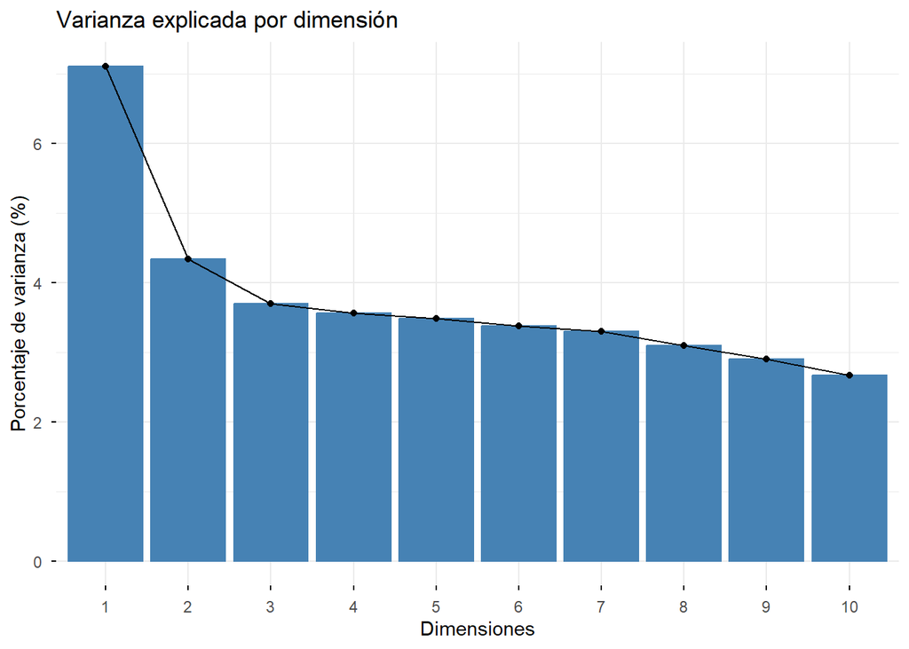

```r
 fviz_screeplot(
   ACM_datos,
   title = "Varianza explicada por dimensión",
   xlab = "Dimensiones",
   ylab = "Porcentaje de varianza (%)"
 )
```

Representación de categoria en la dimensión 1

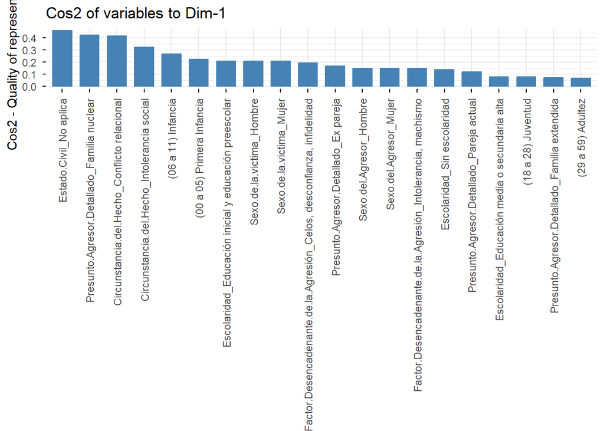

```r
 fviz_cos2(ACM_datos, choice = "var", axes = 1, top = 20) +
   theme(axis.text.x = element_text(angle = 90, vjust = 0.5, hjust = 1))
```

### Representación de los individuos y categorias en los planos factoriales

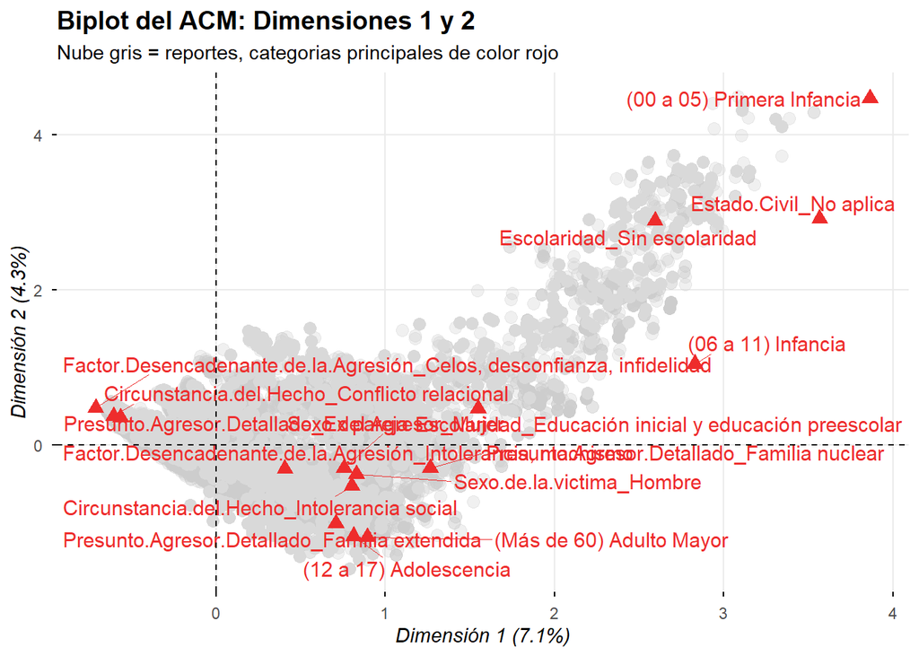

```r
 fviz_mca_biplot(
   ACM_datos,
   # 1. Selección de Dimensiones
   axes = c(1,2),

   # 2. Selección y etiquetas
   select.var = list(contrib = 16),
   label = "var",
   repel = TRUE,
   max.overlaps = Inf,

   # 3. Estética de Individuos (Activos y Suplementarios)
   geom.ind = "point",
   col.ind = "grey80",
   alpha.ind = 0.3,

   col.ind.sup = "grey85",
   alpha.ind.sup = 0.2,

   # 4. Estética de Variables
   col.var = "firebrick2",
   pointsize = 3,

   # 5. Formato y Títulos
   ggtheme = theme_minimal() +
     theme(
       panel.grid.minor = element_blank(),
       plot.title = element_text(face = "bold", size = 14),
       axis.title = element_text(face = "italic")
     )
 ) +
   labs(
     title = "Biplot del ACM: Dimensiones 1 y 2",
     subtitle = "Nube gris = reportes, categorias principales de color rojo",
     x = paste0("Dimensión 1 (", round(ACM_datos$eig[1,2], 1), "%)"),
     y = paste0("Dimensión 2 (", round(ACM_datos$eig[2,2], 1), "%)")
   )
```

Caracterizando por sexo de la victima

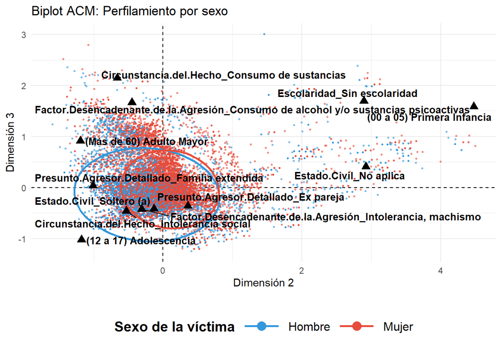

```r
 # 1. Extraer individuos ACTIVOS
 ind_act <- as.data.frame(ACM_datos$ind$coord[, 2:3])
 nombres_act <- rownames(ind_act)


 ind_act$Sexo <- as.factor(df_clean[nombres_act, "Sexo.de.la.victima", drop = TRUE])

 # 2. Extraer individuos SUPLEMENTARIOS
 ind_sup <- as.data.frame(ACM_datos$ind.sup$coord[, 2:3])
 nombres_sup <- rownames(ind_sup)


 ind_sup$Sexo <- as.factor(df_clean[nombres_sup, "Sexo.de.la.victima", drop = TRUE])

 # 3. Unir ambos grupos
 todos_ind <- rbind(ind_act, ind_sup)
 colnames(todos_ind) <- c("Dim2", "Dim3", "Sexo")

 # 4. Preparar las 12 categorías que más contribuyen
 res_var <- get_mca_var(ACM_datos)
 df_vars <- data.frame(
   Dim2 = res_var$coord[,2],
   Dim3 = res_var$coord[,3],
   Categoria = rownames(res_var$coord),
   Contrib = res_var$contrib[, 2] + res_var$contrib[, 3]
 )
 df_top12 <- df_vars[order(-df_vars$Contrib), ][1:12, ]

 # 5. GRAFICAR
 ggplot() +

   geom_hline(yintercept = 0, linetype = "dashed", color = "black", linewidth = 0.5) +
   geom_vline(xintercept = 0, linetype = "dashed", color = "black", linewidth = 0.5) +

   # Nube de puntos de TODOS los individuos
   geom_point(data = todos_ind,
              aes(x = Dim2, y = Dim3, color = Sexo),
              alpha = 0.55, size = 0.5) +
   stat_ellipse(data = todos_ind,
                aes(x = Dim2, y = Dim3, color = Sexo, group = Sexo),
                level = 0.95, linewidth = 1) +
   geom_point(data = df_top12, aes(x = Dim2, y = Dim3),
              color = "black", shape = 17, size = 3) +
   geom_text_repel(data = df_top12, aes(x = Dim2, y = Dim3, label = Categoria),
                   color = "black", fontface = "bold", size = 3.5, max.overlaps = 20) +


   scale_color_manual(values = c("Hombre" = "#3498DB", "Mujer" = "#E74C3C")) +
   theme_minimal() +
   labs(title = "Biplot ACM: Perfilamiento por sexo",
        x = "Dimensión 2", y = "Dimensión 3",
        color = "Sexo de la víctima") +


   theme(
     legend.position = "bottom",
     legend.title = element_text(size = 14, face = "bold"), # Tamaño del título "Sexo de la víctima"
     legend.text = element_text(size = 12),               # Tamaño de "Hombre" / "Mujer"
     legend.key.size = unit(1.5, "cm")                    # Aumenta el espacio del icono
   ) +


   guides(color = guide_legend(override.aes = list(size = 4, alpha = 1)))
```

Caracterizando por contexto del hecho

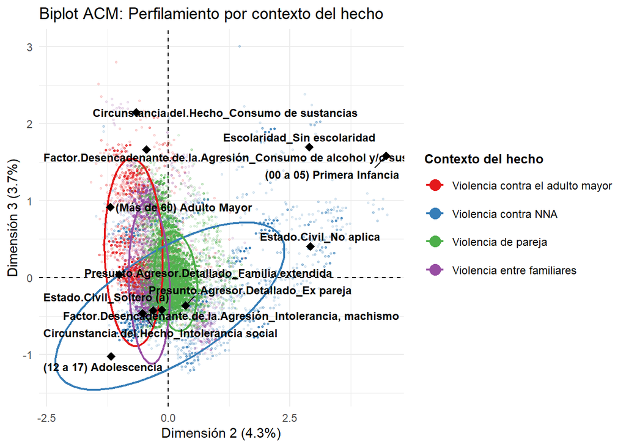

```r
 #  Extraer coordenadas de individuos ACTIVOS (Dims 1 y 2)
 ind_act <- as.data.frame(ACM_datos$ind$coord[, 2:3])
 colnames(ind_act) <- c("Dim2", "Dim3")

 #  Extraer individuos SUPLEMENTARIOS (Dims 1 y 2)
 ind_sup <- as.data.frame(ACM_datos$ind.sup$coord[, 2:3])
 colnames(ind_sup) <- c("Dim2", "Dim3")


 ind_act$Contexto <- as.factor(df_clean[rownames(ind_act), "Contexto.del.Hecho", drop = TRUE])
 ind_sup$Contexto <- as.factor(df_clean[rownames(ind_sup), "Contexto.del.Hecho", drop = TRUE])

 #  Unir ambos grupos
 todos_ind <- rbind(ind_act, ind_sup)

 #  Preparar las 12 categorías que más contribuyen al plano 1-2
 res_var <- get_mca_var(ACM_datos)
 df_vars <- data.frame(
   Dim2 = res_var$coord[, 2],
   Dim3 = res_var$coord[, 3],
   Categoria = rownames(res_var$coord),
   Contrib = res_var$contrib[, 2] + res_var$contrib[, 3]
 )
 df_top12 <- df_vars[order(-df_vars$Contrib), ][1:12, ]

 #  GRAFICAR
 ggplot() +

   geom_hline(yintercept = 0, linetype = "dashed", color = "black", linewidth = 0.5) +
   geom_vline(xintercept = 0, linetype = "dashed", color = "black", linewidth = 0.5) +
   # Nube de puntos de individuos coloreados por Contexto
   geom_point(data = todos_ind,
              aes(x = Dim2, y = Dim3, color = Contexto),
              alpha = 0.15, size = 0.5) +


   stat_ellipse(data = todos_ind,
                aes(x = Dim2, y = Dim3, color = Contexto, group = Contexto),
                level = 0.95, linewidth = 0.8) +


   geom_point(data = df_top12, aes(x = Dim2, y = Dim3),
              color = "black", shape = 18, size = 3) +

   geom_text_repel(data = df_top12, aes(x = Dim2, y = Dim3, label = Categoria),
                   color = "black", fontface = "bold", size = 3.2, max.overlaps = 20) +


   scale_color_brewer(palette = "Set1") +
   theme_minimal() +
   labs(title = "Biplot ACM: Perfilamiento por contexto del hecho",

        x = paste0("Dimensión 2 (", round(ACM_datos$eig[2,2], 1), "%)"),
        y = paste0("Dimensión 3 (", round(ACM_datos$eig[3,2], 1), "%)"),
        color = "Contexto del hecho") +

   theme(
     legend.position = "right",
     legend.direction = "vertical",
     legend.title = element_text(size = 10, face = "bold"),
     legend.text = element_text(size = 9),
     legend.key.height = unit(0.8, "cm")
   ) +


   guides(color = guide_legend(override.aes = list(size = 4, alpha = 1)))
```

Caracterizando por ciclo vital

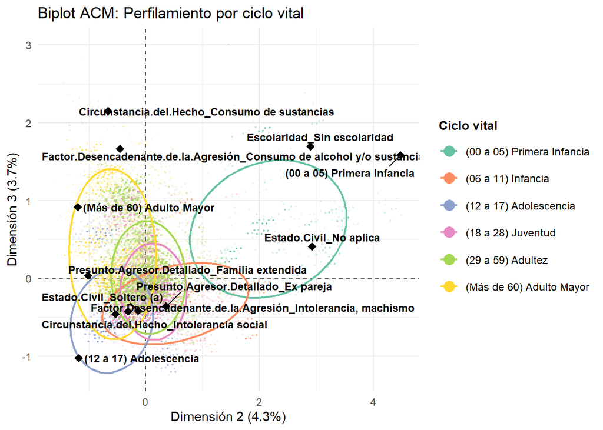

```r
 # Extraer coordenadas de individuos ACTIVOS
 ind_act <- as.data.frame(ACM_datos$ind$coord[, 2:3])
 colnames(ind_act) <- c("Dim2", "Dim3")

 #  Extraer coordenadas de individuos SUPLEMENTARIOS
 ind_sup <- as.data.frame(ACM_datos$ind.sup$coord[, 2:3])
 colnames(ind_sup) <- c("Dim2", "Dim3")


 ind_act$CicloVital <- as.factor(df_clean[rownames(ind_act), "Ciclo.Vital", drop = TRUE])
 ind_sup$CicloVital <- as.factor(df_clean[rownames(ind_sup), "Ciclo.Vital", drop = TRUE])

 #  Unir ambos grupos
 todos_ind <- rbind(ind_act, ind_sup)

 #  Preparar las 12 categorías que más contribuyen (Variables)
 res_var <- get_mca_var(ACM_datos)
 df_vars <- data.frame(
   Dim2 = res_var$coord[, 2],
   Dim3 = res_var$coord[, 3],
   Categoria = rownames(res_var$coord),
   Contrib = res_var$contrib[, 2] + res_var$contrib[, 3]
 )
 df_top12 <- df_vars[order(-df_vars$Contrib), ][1:12, ]

 #  GRAFICAR
 ggplot() +

   geom_hline(yintercept = 0, linetype = "dashed", color = "black", linewidth = 0.5) +
   geom_vline(xintercept = 0, linetype = "dashed", color = "black", linewidth = 0.5) +


   # Nube de puntos de individuos coloreados por Ciclo Vital
   geom_point(data = todos_ind,
              aes(x = Dim2, y = Dim3, color = CicloVital),
              alpha = 0.1, size = 0.4) +


   stat_ellipse(data = todos_ind,
                aes(x = Dim2, y = Dim3, color = CicloVital, group = CicloVital),
                level = 0.95, linewidth = 0.8) +


   geom_point(data = df_top12, aes(x = Dim2, y = Dim3),
              color = "black", shape = 18, size = 3) +

   geom_text_repel(data = df_top12, aes(x = Dim2, y = Dim3, label = Categoria),
                   color = "black", fontface = "bold", size = 3.2, max.overlaps = 25) +


   scale_color_brewer(palette = "Set2") +
   theme_minimal() +
   labs(title = "Biplot ACM: Perfilamiento por ciclo vital",

        x = paste0("Dimensión 2 (", round(ACM_datos$eig[2,2], 1), "%)"),
        y = paste0("Dimensión 3 (", round(ACM_datos$eig[3,2], 1), "%)"),
        color = "Ciclo vital") +
   theme(
     legend.position = "right",
     legend.direction = "vertical",
     legend.title = element_text(size = 10, face = "bold"),
     legend.text = element_text(size = 9),
     legend.key.height = unit(0.8, "cm")
   ) +


   guides(color = guide_legend(override.aes = list(size = 4, alpha = 1)))
```

Caracterizando por circunstancias del hecho

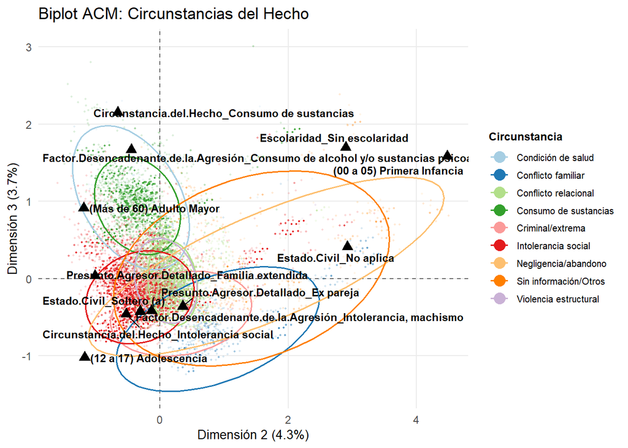

```r
 #  Extraer coordenadas de individuos ACTIVOS
 ind_act <- as.data.frame(ACM_datos$ind$coord[, 2:3])
 colnames(ind_act) <- c("Dim2", "Dim3")

 #  Extraer coordenadas de individuos SUPLEMENTARIOS
 ind_sup <- as.data.frame(ACM_datos$ind.sup$coord[, 2:3])
 colnames(ind_sup) <- c("Dim2", "Dim3")


 ind_act$Circunstancia <- as.factor(df_clean[rownames(ind_act), "Circunstancia.del.Hecho", drop = TRUE])
 ind_sup$Circunstancia <- as.factor(df_clean[rownames(ind_sup), "Circunstancia.del.Hecho", drop = TRUE])

 #  Unir ambos grupos
 todos_ind <- rbind(ind_act, ind_sup)

 #  Preparar las 12 categorías de variables que más contribuyen
 res_var <- get_mca_var(ACM_datos)
 df_vars <- data.frame(
   Dim2 = res_var$coord[, 2],
   Dim3 = res_var$coord[, 3],
   Categoria = rownames(res_var$coord),
   Contrib = res_var$contrib[, 2] + res_var$contrib[, 3]
 )
 df_top12 <- df_vars[order(-df_vars$Contrib), ][1:12, ]

 # 6. GRAFICAR
 ggplot() +
   # Líneas de referencia de los ejes
   geom_hline(yintercept = 0, linetype = "dashed", color = "grey40", linewidth = 0.5) +
   geom_vline(xintercept = 0, linetype = "dashed", color = "grey40", linewidth = 0.5) +

   # Nube de puntos coloreada por Circunstancia
   geom_point(data = todos_ind,
              aes(x = Dim2, y = Dim3, color = Circunstancia),
              alpha = 0.12, size = 0.4) +


   stat_ellipse(data = todos_ind,
                aes(x = Dim2, y = Dim3, color = Circunstancia, group = Circunstancia),
                level = 0.95, linewidth = 0.7) +


   geom_point(data = df_top12, aes(x = Dim2, y = Dim3),
              color = "black", shape = 17, size = 3) +

   geom_text_repel(data = df_top12, aes(x = Dim2, y = Dim3, label = Categoria),
                   color = "black", fontface = "bold", size = 3, max.overlaps = 35) +


   scale_color_brewer(palette = "Paired") +
   theme_minimal() +
   labs(title = "Biplot ACM: Circunstancias del Hecho",

        x = paste0("Dimensión 2 (", round(ACM_datos$eig[2,2], 1), "%)"),
        y = paste0("Dimensión 3 (", round(ACM_datos$eig[3,2], 1), "%)"),
        color = "Circunstancia") +

   theme(
     legend.position = "right",
     legend.direction = "vertical",
     legend.title = element_text(size = 9, face = "bold"),
     legend.text = element_text(size = 7.5),
     legend.key.height = unit(0.5, "cm"),
     panel.grid.minor = element_blank(),
     axis.title = element_text(size = 10)
   ) +


   guides(color = guide_legend(override.aes = list(size = 4, alpha = 1)))
```

Solo si se quieren descargar los valores propios y demas valores

```r
 df_eig <- as.data.frame(get_eigenvalue(ACM_datos))
 df_eig$Dimension <- rownames(df_eig)
 df_eig <- df_eig[order(-df_eig$variance.percent), ]
 df_eig <- df_eig[, c("Dimension", "eigenvalue", "variance.percent", "cumulative.variance.percent")]

 write_xlsx(df_eig, "sin_1_Autovalores_Ordenado.xlsx")


 df_eta2 <- as.data.frame(ACM_datos$var$eta2)
 df_eta2$Variable <- rownames(df_eta2)

 df_eta2 <- df_eta2[order(-df_eta2[, 1]), ]
 df_eta2 <- df_eta2[, c(ncol(df_eta2), 1:(ncol(df_eta2)-1))]

 write_xlsx(df_eta2, "sin_2_Variables_Eta2_Ordenado.xlsx")





 res_var <- get_mca_var(ACM_datos)


 tabla_maestra <- data.frame(
   Categoria = rownames(res_var$contrib),
   Contrib_D1 = res_var$contrib[,1],
   Cos2_D1    = res_var$cos2[,1],
   Contrib_D2 = res_var$contrib[,2],
   Cos2_D2    = res_var$cos2[,2],
   Contrib_D3 = res_var$contrib[,3],
   Cos2_D3    = res_var$cos2[,3],
   Contrib_D4 = res_var$contrib[,4],
   Cos2_D4    = res_var$cos2[,4]
 )


 tabla_maestra_ordenada <- tabla_maestra[order(-tabla_maestra$Contrib_D1), ]

 write_xlsx(tabla_maestra_ordenada, "sin_3_Tabla_Maestra_Categorias_Ordenada.xlsx")
```

# FUZZY C-MEANS

La determinación del número de clústeres se realiza mediante métodos tradicionales como el criterio del codo (WSS) y el índice de silueta, utilizando k-means como aproximación inicial.Posteriormente, se evalúa la calidad de la partición en el contexto de clustering difuso mediante métricas como el Partition Coefficient (PC) y la Partition Entropy (PE). Debido al alto costo computacional, estos procedimientos se aplican sobre una muestra del conjunto de datos.

```r
 coords <- ACM_datos$ind$coord




  datos_fuzzy <- ACM_datos$ind$coord[, 1:4]

  set.seed(12345)

  datos_muestra <- datos_fuzzy[sample(seq_len(nrow(datos_fuzzy)), 20000), ]

  fviz_nbclust(
    datos_muestra[,1:4],
    kmeans,
    method = "wss",
    nstart = 50
  )
```

[output not shown]

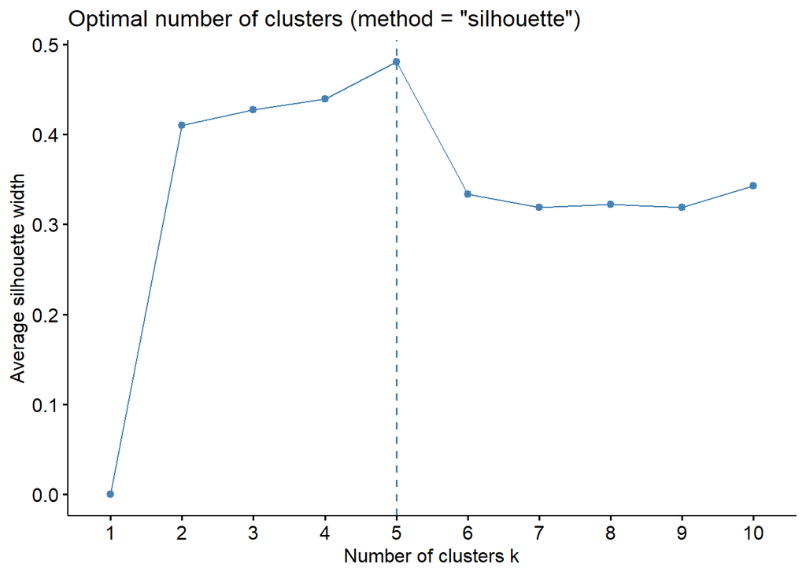

```r
 coords <- ACM_datos$ind$coord




  datos_fuzzy <- ACM_datos$ind$coord[, 1:4]

  set.seed(12345)

  datos_muestra <- datos_fuzzy[sample(seq_len(nrow(datos_fuzzy)), 20000), ]

 fviz_nbclust(
    datos_muestra[,1:4],
    kmeans,
    method = "silhouette",
    nstart = 50
  )
```

Se evalúan distintas configuraciones del número de clústeres (k = 3, 4 y 5) utilizando métricas Partition Coefficient (PC) y la Partition Entropy (PE), con el fin de analizar la calidad de la partición.

Entre mayor sea el coeficiente de partición y entre menor sea la partición de entropia mejor, por lo tanto lo mejor es encontrar un buen punto de equilibrio entre las dos metricas.

```r
 evaluar_custom_k <- function(data, ks, m_val = 2) {
   resultados <- data.frame(k = integer(), PC = numeric(), PE = numeric())

   for (k in ks) {
     cat("Procesando k =", k, "...\n")


     res_fcm <- fcm(data, centers = k, m = m_val, nstart = 5)

     # Extraer matriz de membresía
     u <- res_fcm$u
     n <- nrow(u)

     # --- Cálculo Manual de Métricas ---

     # Partition Coefficient (PC) - Meta: Cercano a 1
     pc_val <- sum(u^2) / n

     # Partition Entropy (PE) - Meta: Cercano a 0
     u_log <- u * log(u)
     u_log[is.nan(u_log)] <- 0
     pe_val <- -sum(u_log) / n

     # Guardar en el dataframe
     resultados <- rbind(resultados, data.frame(k = k, PC = pc_val, PE = pe_val))
   }

   cat("¡Finalizado!\n")
   return(resultados)
 }

 # --- EJEMPLO DE USO ---


 mis_k_interes <- c(3,4,5)


 metricas_finales <- evaluar_custom_k(datos_muestra, ks = mis_k_interes)
```

```
## Procesando k = 3 ...
## Procesando k = 4 ...
## Procesando k = 5 ...
## ¡Finalizado!
```

```r
 print(metricas_finales)
```

```
##   k        PC        PE
## 1 3 0.6482818 0.6362054
## 2 4 0.6478356 0.6831897
## 3 5 0.5194486 0.9275557
```

Se decide agrupar con 4 clusters

```r
 coord_activos <- ACM_datos$ind$coord[, 1:4]
 coord_suplem  <- ACM_datos$ind.sup$coord[, 1:4]
 coord_totales <- rbind(coord_activos, coord_suplem)



 ids_totales <- c(
   rownames(ACM_datos$ind$coord),
   rownames(ACM_datos$ind.sup$coord)
 )







 # 2. Ejecutar Fuzzy C-Means
 # Usando  k=4
 set.seed(4444)
 res_fuzzy <- fcm(coord_totales, centers = 4, m = 2)


 datos_1$id <- as.character(datos_1$id)

 #  Extraer la pertenencia "Hard" (El grupo con mayor probabilidad)
 cluster_asignado <- apply(res_fuzzy$u, 1, which.max)

 df_clusters <- data.frame(
   id = ids_totales,
   Cluster_Fuzzy = cluster_asignado
 )
df_clusters$id <- as.character(df_clusters$id)
 df_final <- datos_1 %>%
   left_join(df_clusters, by = "id")

 df_final <- df_final %>%
   mutate(
     Cluster_Fuzzy2 = case_when(
       Cluster_Fuzzy == 1 ~ "Cluster 1: violencia de pareja: actual y expareja",
       Cluster_Fuzzy == 2 ~ "Cluster 2: violencia relacional asociada a sustancias",
       Cluster_Fuzzy == 3 ~ "Cluster 3: violencia contra NNA",
       Cluster_Fuzzy == 4 ~ "Cluster 4: violencia mixta o transicional",
       TRUE ~ NA_character_
     )
   )
 df_final$Cluster_Fuzzy <- as.factor(df_final$Cluster_Fuzzy)

 table(df_final$Cluster_Fuzzy2, useNA = "always")
```

```
##
##     Cluster 1: violencia de pareja: actual y expareja
##                                                 32723
## Cluster 2: violencia relacional asociada a sustancias
##                                                  8217
##                       Cluster 3: violencia contra NNA
##                                                  2424
##             Cluster 4: violencia mixta o transicional
##                                                 16553
##                                                  <NA>
##                                                     0
```

```r
 table(df_final$Cluster_Fuzzy, useNA = "always")
```

```
##
##     1     2     3     4  <NA>
## 32723  8217  2424 16553     0
```

```r
 names(df_final) <- make.names(names(df_final))

 # Comparar porcentajes de Contexto por Cluster

 prop.table(table(df_final$Cluster_Fuzzy, df_final$Contexto.del.Hecho), 1) * 100
```

```
##
##     Violencia contra el adulto mayor Violencia contra NNA Violencia de pareja
##   1                      0.009167864          0.006111909        99.254347095
##   2                     10.916392844          7.886089814        45.734452963
##   3                      0.660066007         99.009900990         0.000000000
##   4                     11.568899897         19.011659518        21.113997463
##
##     Violencia entre familiares
##   1                0.730373132
##   2               35.463064379
##   3                0.330033003
##   4               48.305443122
```

```r
 # Comparar porcentajes de Sexo por Cluster
 prop.table(table(df_final$Cluster_Fuzzy, df_final$Sexo.de.la.victima), 1) * 100
```

```
##
##        Hombre     Mujer
##   1  7.875195 92.124805
##   2 27.783863 72.216137
##   3 56.270627 43.729373
##   4 46.801184 53.198816
```

```r
 # Comparar porcentajes de ciclo vital por Cluster
 prop.table(table(df_final$Cluster_Fuzzy, df_final$Ciclo.Vital), 1) * 100
```

```
##
##     (00 a 05) Primera Infancia (06 a 11) Infancia (12 a 17) Adolescencia
##   1                  0.0000000          0.0000000              1.3782355
##   2                  0.0000000          1.0344408              7.6183522
##   3                 42.0792079         56.5594059              0.3712871
##   4                  0.0000000          3.6670090             16.8005800
##
##     (18 a 28) Juventud (29 a 59) Adultez (Más de 60) Adulto Mayor
##   1         38.8045106        58.9371390                0.8801149
##   2         19.3501278        57.8313253               14.1657539
##   3          0.0000000         0.3300330                0.6600660
##   4         18.5041986        46.8313901               14.1968223
```

```r
 # Comparar porcentajes de circunstancia del hecho por Cluster
 prop.table(table(df_final$Cluster_Fuzzy, df_final$Circunstancia.del.Hecho), 1) * 100
```

```
##
##     Condición de salud Conflicto familiar Conflicto relacional
##   1        0.009167864        0.000000000         85.303914678
##   2        1.740294511        5.658999635         18.291347207
##   3        0.412541254       10.849834983          1.485148515
##   4        0.024164804        0.604120099         12.565698061
##
##     Consumo de sustancias Criminal/extrema Intolerancia social
##   1           1.054304312      0.024447636        10.445252575
##   2          62.443714251      0.000000000         7.910429597
##   3           7.178217822      0.206270627        66.955445545
##   4           0.084576814      0.078535613        85.114480759
##
##     Negligencia/abandono Sin información/Otros Violencia estructural
##   1          0.061119091           0.165021544           2.936772301
##   2          0.060849458           2.981623464           0.912741877
##   3          4.455445545           8.085808581           0.371287129
##   4          0.217483236           0.060412010           1.250528605
```

```r
 # Comparar porcentajes de presunto agresor por Cluster
 prop.table(table(df_final$Cluster_Fuzzy, df_final$Presunto.Agresor.Detallado), 1) * 100
```

```
##
##         Cuidador    Ex pareja Familia extendida Familia nuclear Pareja actual
##   1  0.003055955 55.881184488       0.391162180     0.351434771  43.373162607
##   2  0.085189242  9.309967141      18.619934283    33.406352683  36.059389071
##   3  3.630363036  0.000000000      10.643564356    83.457095710   0.000000000
##   4  0.199359633 10.831873376      32.260013291    46.426629614  10.276082885
##
##     Sin información
##   1     0.000000000
##   2     2.519167579
##   3     2.268976898
##   4     0.006041201
```

```r
 # Se seleccionan las variables que quedaran para el perfilamiento final de los clusters
 columnas_perfil <- c("Sexo.de.la.victima",

                      "Ciclo.Vital",
                      "Escolaridad",
                      "Estado.Civil",
                      "Pertenencia.Grupal",
                      "Zona.del.Hecho",
                      "Escenario.del.Hecho",
                      "Actividad.Durante.el.Hecho",
                      "Circunstancia.del.Hecho",
                      "Contexto.del.Hecho",
                      "Sexo.del.Agresor",
                      "Presunto.Agresor.Detallado",
                      "Mecanismo.Causal.de.la.Lesión.no.Fatal",
                      "Diagnostico.Topográfico.de.la.Lesión.no.Fatal",
                      "Factor.Desencadenante.de.la.Agresión",
                      "Días.de.Incapacidad.Medicolegal",
                      "Tipo.de.Discapacidad",
                      "Orientación.Sexual")



 # Se crea la función para extraer la moda (categoría más frecuente)
 get_mode <- function(x) {
   ux <- unique(na.omit(x))
   ux[which.max(tabulate(match(x, ux)))]
 }

 #  tabla resumen
 tabla_perfiles <- df_final %>%
   group_by(Cluster_Fuzzy) %>%
   summarise(across(all_of(columnas_perfil), get_mode))


 print(tabla_perfiles)
```

```
## # A tibble: 4 × 19
##   Cluster_Fuzzy Sexo.de.la.victima Ciclo.Vital        Escolaridad   Estado.Civil
##   <fct>         <chr>              <chr>              <chr>         <chr>
## 1 1             Mujer              (29 a 59) Adultez  Educación me… Soltero (a)
## 2 2             Mujer              (29 a 59) Adultez  Educación me… Unión libre
## 3 3             Hombre             (06 a 11) Infancia Educación in… No aplica
## 4 4             Mujer              (29 a 59) Adultez  Educación me… Soltero (a)
## # ℹ 14 more variables: Pertenencia.Grupal <chr>, Zona.del.Hecho <chr>,
## #   Escenario.del.Hecho <chr>, Actividad.Durante.el.Hecho <chr>,
## #   Circunstancia.del.Hecho <chr>, Contexto.del.Hecho <chr>,
## #   Sexo.del.Agresor <chr>, Presunto.Agresor.Detallado <chr>,
## #   Mecanismo.Causal.de.la.Lesión.no.Fatal <chr>,
## #   Diagnostico.Topográfico.de.la.Lesión.no.Fatal <chr>,
## #   Factor.Desencadenante.de.la.Agresión <chr>, …
```

```r
  # matriz de pertenencia (u)
  matriz_u <- as.data.frame(res_fuzzy$u)

  #  Se calcula la pertenencia máxima por individuo
  df_final$pertenencia_max <- apply(matriz_u, 1, max)

  #estadísticas descriptivas de la certeza
  summary(df_final$pertenencia_max)
```

```
##    Min. 1st Qu.  Median    Mean 3rd Qu.    Max.
##  0.2546  0.6315  0.8228  0.7543  0.8950  0.9944
```

El promedio de pertenencia de cada punto de pertenecer a un cluster es de 0.75, lo cual significa que en general cada punto esta bien definido por un cluster

```r
  # Se crean las etiquetas de seguridad en la asignación
  df_final$tipo_pertenencia <- cut(df_final$pertenencia_max,
                                   breaks = c(0, 0.4, 0.7, 1),
                                   labels = c("Muy Ambiguo [0 , 0.4]", "Intermedio [0.4 , 0.7]", "Perfil Claro [0.7 , 1]"))

  # Cantidad de reportes en cada intervalo
  tabla_ambiguedad <- table(df_final$tipo_pertenencia)
  print(tabla_ambiguedad)
```

```
##
##  Muy Ambiguo [0 , 0.4] Intermedio [0.4 , 0.7] Perfil Claro [0.7 , 1]
##                   2291                  17357                  40269
```

```r
  # Porcentaje de solapamiento
  prop.table(tabla_ambiguedad) * 100
```

```
##
##  Muy Ambiguo [0 , 0.4] Intermedio [0.4 , 0.7] Perfil Claro [0.7 , 1]
##               3.823623              28.968406              67.207971
```

El 67.20% de las asignaciones son claras, el 28.96% estan en un nivel intermedio y el 3.82% son muy difusas

Certeza promedio por cada cluster:

```r
  df_final %>%
    group_by(Cluster_Fuzzy) %>%
    summarise(Certeza_Promedio = mean(pertenencia_max))
```

```
## # A tibble: 4 × 2
##   Cluster_Fuzzy Certeza_Promedio
##   <fct>                    <dbl>
## 1 1                        0.760
## 2 2                        0.756
## 3 3                        0.720
## 4 4                        0.748
```

```r
  # Creacción de matriz Gap
  p1 <- apply(matriz_u, 1, function(x) sort(x, decreasing = TRUE)[1])
  p2 <- apply(matriz_u, 1, function(x) sort(x, decreasing = TRUE)[2])


  df_final$gap_pertenencia <- p1 - p2


  casos_puente_pro <- df_final[df_final$gap_pertenencia < 0.1, ]

  nrow(casos_puente_pro)
```

```
## [1] 4302
```

```r
  # Calculo de entropia
  calcular_entropia <- function(probabilidades) {
    probabilidades <- probabilidades[probabilidades > 0]
    -sum(probabilidades * log2(probabilidades))
  }

  df_final$entropia <- apply(matriz_u, 1, calcular_entropia)

  # Normalizar la entropía (de 0 a 1, donde 1 es máxima confusión)
  # Para 4 clusters, el log2(4) es 2.
  df_final$entropia_norm <- df_final$entropia / log2(4)

  summary(df_final$entropia_norm)
```

```
##    Min. 1st Qu.  Median    Mean 3rd Qu.    Max.
## 0.02848 0.31218 0.45408 0.49905 0.71478 0.99981
```

```r
  colnames(matriz_u) <- paste0("Cluster_", 1:ncol(matriz_u))

  df_final$top_cluster1 <- apply(matriz_u, 1, function(x) colnames(matriz_u)[order(x, decreasing = TRUE)[1]])
  df_final$top_cluster2 <- apply(matriz_u, 1, function(x) colnames(matriz_u)[order(x, decreasing = TRUE)[2]])
  # Crear una matriz de "Confusión Interna" para los casos ambiguos (Gap < 0.15)
  tabla_solapamiento <- df_final %>%
    filter(gap_pertenencia < 0.15) %>%
    group_by(top_cluster1, top_cluster2) %>%
    tally() %>%
    spread(top_cluster2, n, fill = 0)

  print(tabla_solapamiento)
```

```
## # A tibble: 4 × 5
## # Groups:   top_cluster1 [4]
##   top_cluster1 Cluster_1 Cluster_2 Cluster_3 Cluster_4
##   <chr>            <dbl>     <dbl>     <dbl>     <dbl>
## 1 Cluster_1            0      1069         0      1631
## 2 Cluster_2         1174         0        18       772
## 3 Cluster_3            2        55         0       133
## 4 Cluster_4          966       589       117         0
```

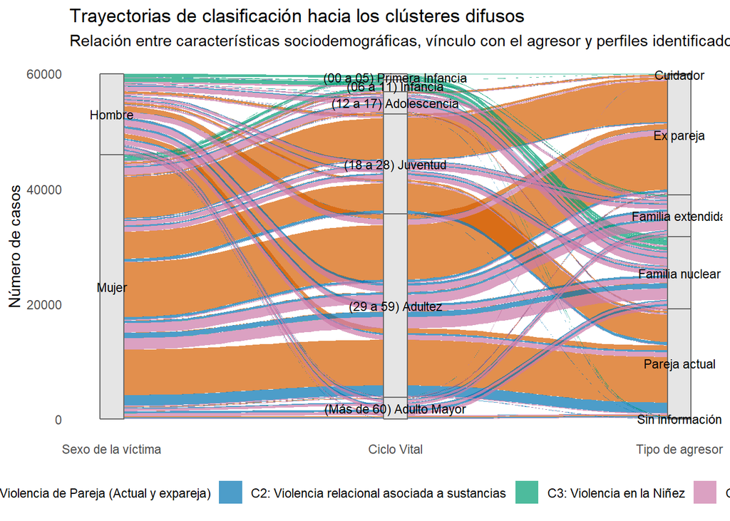

```r
  # Grafico de trayectoria


  df_aluvial <- df_final %>%
    group_by(Sexo.de.la.victima, Ciclo.Vital, Presunto.Agresor.Detallado, Cluster_Fuzzy) %>%
    tally() %>%
    ungroup()


  ggplot(data = df_aluvial,
         aes(axis1 = Sexo.de.la.victima,
             axis2 = Ciclo.Vital,
             axis3 = Presunto.Agresor.Detallado,
             y = n)) +

    geom_alluvium(aes(,fill = as.factor(Cluster_Fuzzy)), width = 1/12, alpha = 0.7) +
    geom_stratum(width = 1/12, fill = "grey90", color = "grey40") +
    geom_text(stat = "stratum", aes(label = after_stat(stratum)), size = 3) +


    scale_fill_manual(
      values = c("#D55E00", "#0072B2", "#009E73", "#CC79A7"),
      labels = c(
        "C1: Violencia de Pareja (Actual y expareja)",
        "C2: Violencia relacional asociada a sustancias",
        "C3: Violencia en la Niñez",
        "C4: Violencia mixta o transicional"
      )
    ) +


    scale_x_discrete(
      limits = c("Sexo de la víctima", "Ciclo Vital", "Tipo de agresor"),
      expand = c(.05, .05)
    ) +

    theme_minimal() +
    labs(
      title = "Trayectorias de clasificación hacia los clústeres difusos",
      subtitle = "Relación entre características sociodemográficas, vínculo con el agresor y perfiles identificados",
      y = "Número de casos",
      fill = "Clúster"
    ) +

    theme(
      legend.position = "bottom",
      panel.grid.major = element_blank(),
      panel.grid.minor = element_blank()
    )
```

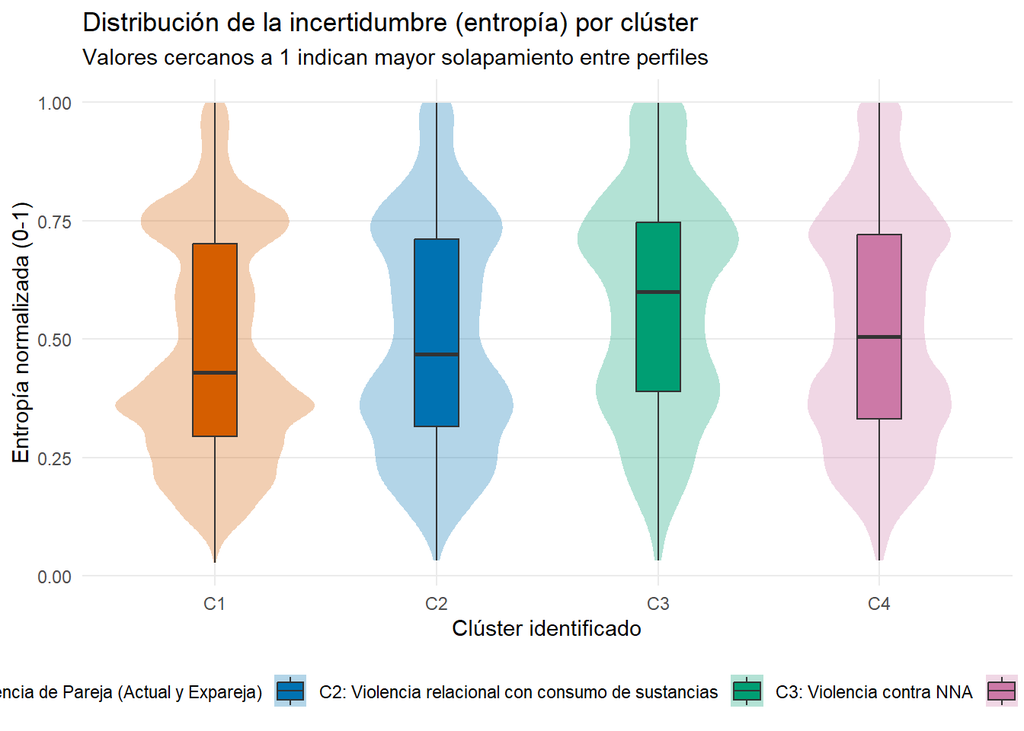

```r
  # Grafico de violin
  ggplot(df_final, aes(x = as.factor(Cluster_Fuzzy), y = entropia_norm, fill = as.factor(Cluster_Fuzzy))) +


    geom_violin(alpha = 0.3, color = NA) +


    geom_boxplot(width = 0.2, color = "grey20", outlier.alpha = 0.1) +


    scale_fill_manual(
      values = c("#D55E00", "#0072B2", "#009E73", "#CC79A7"),
      labels = c(
        "C1: Violencia de Pareja (Actual y Expareja)",
        "C2: Violencia relacional con consumo de sustancias",
        "C3: Violencia contra NNA",
        "C4: Violencia Mixta o transacional"
      )
    ) +


    scale_x_discrete(labels = c(
      "1" = "C1",
      "2" = "C2",
      "3" = "C3",
      "4" = "C4"
    )) +

    theme_minimal() +
    labs(
      title = "Distribución de la incertidumbre (entropía) por clúster",
      subtitle = "Valores cercanos a 1 indican mayor solapamiento entre perfiles",
      x = "Clúster identificado",
      y = "Entropía normalizada (0-1)",
      fill = "Clúster"
    ) +

    theme(
      legend.position = "bottom",
      panel.grid.minor = element_blank()
    )
```

```r
  #GRAFICO 3D


  todos_3d <- data.frame(
    id = ids_totales,
    Dim1 = coord_totales[,1],
    Dim2 = coord_totales[,2],
    Dim3 = coord_totales[,3]
  )

  todos_3d <- todos_3d %>%
    left_join(df_clusters, by = "id")



  todos_3d$Cluster <- factor(
    todos_3d$Cluster_Fuzzy,
    levels = c(1,2,3,4),
    labels = c(
      "C1: Violencia de Pareja (Actual y Expareja)",
      "C2: Violencia relacional con consumo de sustancias",
      "C3: Violencia contra NNA",
      "C4: Violencia Mixta o transacional"
    )
  )

  # 2. Plot
  fig <- plot_ly(
    todos_3d,
    x = ~Dim1, y = ~Dim2, z = ~Dim3,
    color = ~Cluster,
    colors = c("#D55E00", "#0072B2", "#009E73", "#CC79A7"),
    type = 'scatter3d',
    mode = 'markers',

    # SOLO puntos del plano (pequeños)
    marker = list(size = 2, opacity = 0.4)
  ) %>%


    layout(
      title = "Espacio Factorial 3D: Perfiles de Violencia",

      legend = list(
        title = list(text = "<b>Clusters</b>"),
        itemsizing = "constant"
      ),

      scene = list(
        xaxis = list(title = 'Dimensión 1'),
        yaxis = list(title = 'Dimensión 2'),
        zaxis = list(title = 'Dimensión 3')
      )
    )

  fig
```

[interactive chart not shown]

VISUALIZACIÓN DE LOS CLUSTERS SOBRE EL PLANO FACTORIAL DEL ACM DIMENIONES 2 Y 3

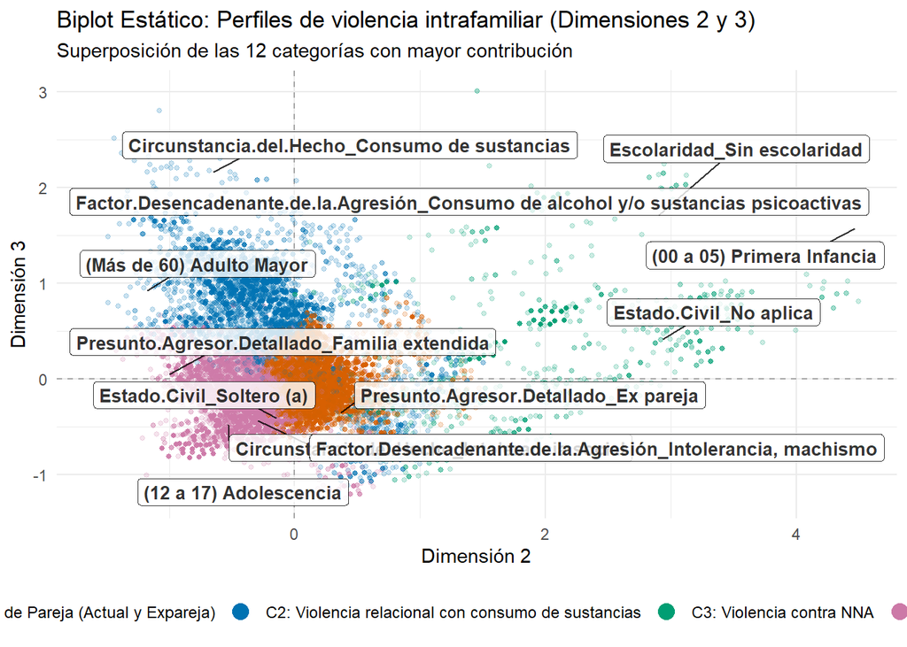

```r
  colores_clusters <- c(
    "C1: Violencia de Pareja (Actual y Expareja)" = "#D55E00",
    "C2: Violencia relacional con consumo de sustancias" = "#0072B2",
    "C3: Violencia contra NNA" = "#009E73",
    "C4: Violencia Mixta o transacional" = "#CC79A7"
  )



  var_coords <- as.data.frame(ACM_datos$var$coord[, 2:3])
  colnames(var_coords) <- c("Dim2", "Dim3")


  var_contrib <- rowSums(ACM_datos$var$contrib[, 2:3])
  top_12_cat <- names(sort(var_contrib, decreasing = TRUE)[1:12])
  var_coords_top <- var_coords[top_12_cat, ]
  var_coords_top$Categoria <- rownames(var_coords_top)


  ggplot() +

    geom_hline(yintercept = 0, linetype = "dashed", alpha = 0.3) +
    geom_vline(xintercept = 0, linetype = "dashed", alpha = 0.3) +


    geom_point(data = todos_3d,
               aes(x = Dim2, y = Dim3, color = Cluster),
               size = 1, alpha = 0.2) +


    geom_label_repel(data = var_coords_top,
                     aes(x = Dim2, y = Dim3, label = Categoria),
                     box.padding = 0.5, segment.color = 'black',
                     fontface = "bold", size = 3.5, fill = "white", alpha = 0.8) +


    scale_color_manual(
      values = colores_clusters
    ) +

    theme_minimal() +
    labs(title = "Biplot Estático: Perfiles de violencia intrafamiliar (Dimensiones 2 y 3)",
         subtitle = "Superposición de las 12 categorías con mayor contribución",
         x = "Dimensión 2",
         y = "Dimensión 3",
         color = "Clúster") +

    theme(
      legend.position = "bottom",
      legend.title = element_text(face = "bold"),
      legend.text = element_text(size = 9)
    ) +


    guides(color = guide_legend(override.aes = list(size = 4, alpha = 1)))
```

VISUALIZACIÓN DE LOS CLUSTERS SOBRE EL PLANO FACTORIAL DEL ACM DIMENIONES 1 Y 2

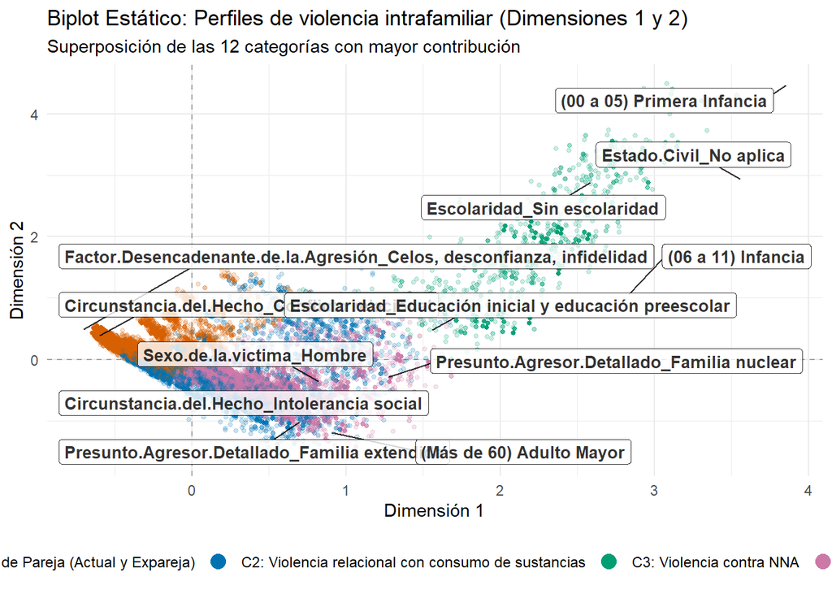

```r
  var_coords <- as.data.frame(ACM_datos$var$coord[, 1:2])
  colnames(var_coords) <- c("Dim1", "Dim2")


  var_contrib <- rowSums(ACM_datos$var$contrib[, 1:2])
  top_12_cat <- names(sort(var_contrib, decreasing = TRUE)[1:12])
  var_coords_top <- var_coords[top_12_cat, ]
  var_coords_top$Categoria <- rownames(var_coords_top)


  ggplot() +

    geom_hline(yintercept = 0, linetype = "dashed", alpha = 0.3) +
    geom_vline(xintercept = 0, linetype = "dashed", alpha = 0.3) +


    geom_point(data = todos_3d,
               aes(x = Dim1, y = Dim2, color = Cluster),
               size = 1, alpha = 0.2) +


    geom_label_repel(data = var_coords_top,
                     aes(x = Dim1, y = Dim2, label = Categoria),
                     box.padding = 0.5, segment.color = 'black',
                     fontface = "bold", size = 3.5, fill = "white", alpha = 0.8) +


    scale_color_manual(
      values = colores_clusters
    ) +

    theme_minimal() +
    labs(title = "Biplot Estático: Perfiles de violencia intrafamiliar (Dimensiones 1 y 2)",
         subtitle = "Superposición de las 12 categorías con mayor contribución",
         x = "Dimensión 1",
         y = "Dimensión 2",
         color = "Clúster") +

    theme(
      legend.position = "bottom",
      legend.title = element_text(face = "bold"),
      legend.text = element_text(size = 9)
    ) +


    guides(color = guide_legend(override.aes = list(size = 4, alpha = 1)))
```